# Ford GoBike Data

## Preliminary Wrangling

> The Ford GoBike dataset contains trip data for bike users in the San Francisco Bay Area, for the years 2017 (from June) and 2018.

```python
# import all packages and set plots to be embedded inline
import numpy as np
import pandas as pd
import matplotlib.pyplot as plt
import seaborn as sb; sb.set()
import zipfile

%matplotlib inline
```

> Load data, provided in the Ford GoBike webpage, for the years of 2017 and 2018: https://www.fordgobike.com/system-data

```python
# gather 2017 data
df_2017 = pd.read_csv('Data/2017-fordgobike-tripdata.csv')
```

```python
# 2018 monthly data - name list
ext_file = ['01', '02', '03', '04', '05', '06',
            '07', '08', '09', '10', '11', '12']
```

```python
# unzip all 2018 monthly files
for i in ext_file:
    with zipfile.ZipFile('Data/2018' + i + '-fordgobike-tripdata.csv.zip', 'r') as myzip:
        myzip.extractall('Data')
```

```python
# gather all 2018 monthly files and append them in a list
list_temp = []
for i in ext_file:
    df_month = pd.read_csv('Data/2018' + i + '-fordgobike-tripdata.csv')
    list_temp.append(df_month)
```

```python
# concatenate all monthly datasets together
df_2018 = pd.concat(list_temp, ignore_index=True)
```

```python
df_2018.info(null_counts=True)
```

```
<class 'pandas.core.frame.DataFrame'>
RangeIndex: 1863721 entries, 0 to 1863720
Data columns (total 16 columns):
duration_sec               1863721 non-null int64
start_time                 1863721 non-null object
end_time                   1863721 non-null object
start_station_id           1851950 non-null float64
start_station_name         1851950 non-null object
start_station_latitude     1863721 non-null float64
start_station_longitude    1863721 non-null float64
end_station_id             1851950 non-null float64
end_station_name           1851950 non-null object
end_station_latitude       1863721 non-null float64
end_station_longitude      1863721 non-null float64
bike_id                    1863721 non-null int64
user_type                  1863721 non-null object
member_birth_year          1753003 non-null float64
member_gender              1753354 non-null object
bike_share_for_all_trip    1863721 non-null object
dtypes: float64(7), int64(2), object(7)
memory usage: 227.5+ MB
```

```python
df_2017.info()
```

```
<class 'pandas.core.frame.DataFrame'>
RangeIndex: 519700 entries, 0 to 519699
Data columns (total 15 columns):
duration_sec               519700 non-null int64
start_time                 519700 non-null object
end_time                   519700 non-null object
start_station_id           519700 non-null int64
start_station_name         519700 non-null object
start_station_latitude     519700 non-null float64
start_station_longitude    519700 non-null float64
end_station_id             519700 non-null int64
end_station_name           519700 non-null object
end_station_latitude       519700 non-null float64
end_station_longitude      519700 non-null float64
bike_id                    519700 non-null int64
user_type                  519700 non-null object
member_birth_year          453159 non-null float64
member_gender              453238 non-null object
dtypes: float64(5), int64(4), object(6)
memory usage: 59.5+ MB
```

```python
# merge together in one dataset the years 2017 and 2018 (tidiness)
df = pd.concat([df_2017, df_2018], ignore_index=True, sort=False)
```

```python
# programmatic assessment
df.info(null_counts=True)
```

```
<class 'pandas.core.frame.DataFrame'>
RangeIndex: 2383421 entries, 0 to 2383420
Data columns (total 16 columns):
duration_sec               2383421 non-null int64
start_time                 2383421 non-null object
end_time                   2383421 non-null object
start_station_id           2371650 non-null float64
start_station_name         2371650 non-null object
start_station_latitude     2383421 non-null float64
start_station_longitude    2383421 non-null float64
end_station_id             2371650 non-null float64
end_station_name           2371650 non-null object
end_station_latitude       2383421 non-null float64
end_station_longitude      2383421 non-null float64
bike_id                    2383421 non-null int64
user_type                  2383421 non-null object
member_birth_year          2206162 non-null float64
member_gender              2206592 non-null object
bike_share_for_all_trip    1863721 non-null object
dtypes: float64(7), int64(2), object(7)
memory usage: 290.9+ MB
```

### Data Assessment

```python
# visual assessment
df.head()
```

|  | duration_sec | start_time | end_time | start_station_id | start_station_name | start_station_latitude | start_station_longitude | end_station_id | end_station_name | end_station_latitude | end_station_longitude | bike_id | user_type | member_birth_year | member_gender | bike_share_for_all_trip |
| --- | --- | --- | --- | --- | --- | --- | --- | --- | --- | --- | --- | --- | --- | --- | --- | --- |
| 0 | 80110 | 2017-12-31 16:57:39.6540 | 2018-01-01 15:12:50.2450 | 74.0 | Laguna St at Hayes St | 37.776435 | -122.426244 | 43.0 | San Francisco Public Library (Grove St at Hyde... | 37.778768 | -122.415929 | 96 | Customer | 1987.0 | Male | NaN |
| 1 | 78800 | 2017-12-31 15:56:34.8420 | 2018-01-01 13:49:55.6170 | 284.0 | Yerba Buena Center for the Arts (Howard St at ... | 37.784872 | -122.400876 | 96.0 | Dolores St at 15th St | 37.766210 | -122.426614 | 88 | Customer | 1965.0 | Female | NaN |
| 2 | 45768 | 2017-12-31 22:45:48.4110 | 2018-01-01 11:28:36.8830 | 245.0 | Downtown Berkeley BART | 37.870348 | -122.267764 | 245.0 | Downtown Berkeley BART | 37.870348 | -122.267764 | 1094 | Customer | NaN | NaN | NaN |
| 3 | 62172 | 2017-12-31 17:31:10.6360 | 2018-01-01 10:47:23.5310 | 60.0 | 8th St at Ringold St | 37.774520 | -122.409449 | 5.0 | Powell St BART Station (Market St at 5th St) | 37.783899 | -122.408445 | 2831 | Customer | NaN | NaN | NaN |
| 4 | 43603 | 2017-12-31 14:23:14.0010 | 2018-01-01 02:29:57.5710 | 239.0 | Bancroft Way at Telegraph Ave | 37.868813 | -122.258764 | 247.0 | Fulton St at Bancroft Way | 37.867789 | -122.265896 | 3167 | Subscriber | 1997.0 | Female | NaN |

```python
# visual assessment
df.sample(10)
```

|  | duration_sec | start_time | end_time | start_station_id | start_station_name | start_station_latitude | start_station_longitude | end_station_id | end_station_name | end_station_latitude | end_station_longitude | bike_id | user_type | member_birth_year | member_gender | bike_share_for_all_trip |
| --- | --- | --- | --- | --- | --- | --- | --- | --- | --- | --- | --- | --- | --- | --- | --- | --- |
| 881832 | 410 | 2018-04-20 17:55:28.5540 | 2018-04-20 18:02:19.1490 | 310.0 | San Fernando St at 4th St | 37.335885 | -121.885660 | 310.0 | San Fernando St at 4th St | 37.335885 | -121.885660 | 2400 | Subscriber | 1990.0 | Male | Yes |
| 160192 | 920 | 2017-11-07 09:20:39.5910 | 2017-11-07 09:35:59.6080 | 150.0 | Adeline St at 40th St | 37.831277 | -122.278267 | 180.0 | Telegraph Ave at 23rd St | 37.812678 | -122.268773 | 109 | Subscriber | 1994.0 | Male | NaN |
| 105988 | 4283 | 2017-11-24 15:41:45.3190 | 2017-11-24 16:53:09.0660 | 44.0 | Civic Center/UN Plaza BART Station (Market St ... | 37.781074 | -122.411738 | 33.0 | Golden Gate Ave at Hyde St | 37.781650 | -122.415408 | 2188 | Subscriber | 1960.0 | Male | NaN |
| 1066606 | 1453 | 2018-05-14 09:20:28.6620 | 2018-05-14 09:44:41.9480 | 126.0 | Esprit Park | 37.761634 | -122.390648 | 10.0 | Washington St at Kearny St | 37.795393 | -122.404770 | 1627 | Subscriber | NaN | NaN | No |
| 1234548 | 854 | 2018-06-17 16:43:50.4190 | 2018-06-17 16:58:05.0940 | 14.0 | Clay St at Battery St | 37.795001 | -122.399970 | 90.0 | Townsend St at 7th St | 37.771058 | -122.402717 | 3829 | Subscriber | 1988.0 | Female | No |
| 1345998 | 654 | 2018-07-31 05:53:34.5080 | 2018-07-31 06:04:29.0780 | 96.0 | Dolores St at 15th St | 37.766210 | -122.426614 | 19.0 | Post St at Kearny St | 37.788975 | -122.403452 | 3963 | Subscriber | 1985.0 | Female | No |
| 1633049 | 188 | 2018-08-16 11:29:27.5310 | 2018-08-16 11:32:36.2790 | 81.0 | Berry St at 4th St | 37.775880 | -122.393170 | 93.0 | 4th St at Mission Bay Blvd S | 37.770407 | -122.391198 | 2445 | Subscriber | 1971.0 | Other | No |
| 709909 | 487 | 2018-02-03 16:52:43.5400 | 2018-02-03 17:00:51.1900 | 269.0 | Telegraph Ave at Carleton St | 37.862320 | -122.258801 | 167.0 | College Ave at Harwood Ave | 37.848152 | -122.252160 | 2215 | Subscriber | 1983.0 | Male | No |
| 2160032 | 511 | 2018-11-18 17:00:55.9510 | 2018-11-18 17:09:27.9110 | 72.0 | Page St at Scott St | 37.772406 | -122.435650 | 88.0 | 11th St at Bryant St | 37.770030 | -122.411726 | 527 | Subscriber | 1964.0 | Male | No |
| 668375 | 332 | 2018-02-13 18:11:58.8510 | 2018-02-13 18:17:31.1550 | 30.0 | San Francisco Caltrain (Townsend St at 4th St) | 37.776598 | -122.395282 | 89.0 | Division St at Potrero Ave | 37.769218 | -122.407646 | 3454 | Subscriber | 1979.0 | Male | No |

I merged data from 2017 and 2018 years together, since each type of observetional unit should form a table (tidiness) and it will help me in my analysis.

We can already see some issues in the data above. For example missing values (e.g. for member birth year) or datatype issues (e.g. for station id or bike id). Let's look more carefully into the data.

First, I can see some columns which, for now, I don't plan to use them in my analysis.

- start_station_latitude
- start_station_longitude
- end_station_latitude
- end_station_longitude

I will discuss this again later, since it depends on the research questions I will try to explore if I will keep or remove these columns.

```python
# duplicates
df.duplicated().sum()
```

```
0
```

```python
# null values
df.isnull().sum()
```

```
duration_sec                    0
start_time                      0
end_time                        0
start_station_id            11771
start_station_name          11771
start_station_latitude          0
start_station_longitude         0
end_station_id              11771
end_station_name            11771
end_station_latitude            0
end_station_longitude           0
bike_id                         0
user_type                       0
member_birth_year          177259
member_gender              176829
bike_share_for_all_trip    519700
dtype: int64
```

```python
# explore null values
df[df.start_station_id.isnull()]
```

|  | duration_sec | start_time | end_time | start_station_id | start_station_name | start_station_latitude | start_station_longitude | end_station_id | end_station_name | end_station_latitude | end_station_longitude | bike_id | user_type | member_birth_year | member_gender | bike_share_for_all_trip |
| --- | --- | --- | --- | --- | --- | --- | --- | --- | --- | --- | --- | --- | --- | --- | --- | --- |
| 1143064 | 5572 | 2018-06-30 20:58:31.8550 | 2018-06-30 22:31:24.5930 | NaN | NaN | 37.40 | -121.94 | NaN | NaN | 37.40 | -121.94 | 4202 | Customer | 1989.0 | Male | No |
| 1143076 | 573 | 2018-06-30 22:12:27.5110 | 2018-06-30 22:22:01.1740 | NaN | NaN | 37.40 | -121.94 | NaN | NaN | 37.40 | -121.93 | 4095 | Subscriber | 1994.0 | Male | Yes |
| 1143093 | 850 | 2018-06-30 22:01:25.5850 | 2018-06-30 22:15:36.1510 | NaN | NaN | 37.41 | -121.94 | NaN | NaN | 37.41 | -121.95 | 4122 | Customer | 1990.0 | Male | No |
| 1143129 | 562 | 2018-06-30 21:52:05.1180 | 2018-06-30 22:01:27.4400 | NaN | NaN | 37.41 | -121.94 | NaN | NaN | 37.42 | -121.94 | 4184 | Subscriber | 1989.0 | Male | No |
| 1143156 | 819 | 2018-06-30 21:37:34.5060 | 2018-06-30 21:51:13.7290 | NaN | NaN | 37.41 | -121.94 | NaN | NaN | 37.41 | -121.96 | 4137 | Customer | 1985.0 | Male | No |
| 1143172 | 1176 | 2018-06-30 21:23:30.4880 | 2018-06-30 21:43:07.3310 | NaN | NaN | 37.41 | -121.94 | NaN | NaN | 37.41 | -121.94 | 4152 | Customer | 1961.0 | Male | No |
| 1143179 | 160 | 2018-06-30 21:37:50.9260 | 2018-06-30 21:40:30.9300 | NaN | NaN | 37.41 | -121.94 | NaN | NaN | 37.42 | -121.94 | 4105 | Subscriber | 1990.0 | Female | No |
| 1143248 | 7242 | 2018-06-30 19:19:19.5600 | 2018-06-30 21:20:02.1110 | NaN | NaN | 37.40 | -121.94 | NaN | NaN | 37.40 | -121.94 | 4082 | Customer | 1990.0 | Male | No |
| 1143249 | 725 | 2018-06-30 21:06:44.3580 | 2018-06-30 21:18:50.2180 | NaN | NaN | 37.41 | -121.96 | NaN | NaN | 37.41 | -121.96 | 4156 | Customer | 1983.0 | Male | No |
| 1143250 | 694 | 2018-06-30 21:05:49.6180 | 2018-06-30 21:17:24.2670 | NaN | NaN | 37.40 | -121.93 | NaN | NaN | 37.41 | -121.94 | 4136 | Customer | 1987.0 | Female | No |
| 1143251 | 1608 | 2018-06-30 20:50:23.7450 | 2018-06-30 21:17:12.6390 | NaN | NaN | 37.40 | -121.92 | NaN | NaN | 37.41 | -121.94 | 4184 | Customer | 1986.0 | Male | No |
| 1143263 | 1444 | 2018-06-30 20:49:04.1980 | 2018-06-30 21:13:08.8980 | NaN | NaN | 37.40 | -121.94 | NaN | NaN | 37.40 | -121.94 | 4135 | Customer | 1982.0 | Male | No |
| 1143273 | 3855 | 2018-06-30 20:06:14.4580 | 2018-06-30 21:10:29.5520 | NaN | NaN | 37.40 | -121.93 | NaN | NaN | 37.40 | -121.93 | 4171 | Customer | 1975.0 | Male | No |
| 1143281 | 3344 | 2018-06-30 20:12:39.0470 | 2018-06-30 21:08:23.1120 | NaN | NaN | 37.40 | -121.94 | NaN | NaN | 37.40 | -121.94 | 4110 | Customer | 1988.0 | Female | No |
| 1143300 | 1700 | 2018-06-30 20:30:05.1760 | 2018-06-30 20:58:25.7960 | NaN | NaN | 37.40 | -121.94 | NaN | NaN | 37.40 | -121.94 | 4202 | Subscriber | 1984.0 | Male | No |
| 1143363 | 462 | 2018-06-30 20:31:55.1570 | 2018-06-30 20:39:38.0370 | NaN | NaN | 37.41 | -121.93 | NaN | NaN | 37.40 | -121.92 | 4132 | Subscriber | NaN | NaN | No |
| 1143370 | 1320 | 2018-06-30 20:13:48.8020 | 2018-06-30 20:35:49.6220 | NaN | NaN | 37.40 | -121.92 | NaN | NaN | 37.40 | -121.92 | 4237 | Subscriber | 1988.0 | Male | No |
| 1143396 | 3780 | 2018-06-30 19:25:16.0000 | 2018-06-30 20:28:16.0730 | NaN | NaN | 37.40 | -121.94 | NaN | NaN | 37.40 | -121.94 | 4202 | Customer | 1987.0 | Female | No |
| 1143398 | 328 | 2018-06-30 20:22:16.2300 | 2018-06-30 20:27:44.2720 | NaN | NaN | 37.41 | -121.94 | NaN | NaN | 37.41 | -121.94 | 4092 | Subscriber | 1989.0 | Male | No |
| 1143417 | 1737 | 2018-06-30 19:55:39.7310 | 2018-06-30 20:24:36.7880 | NaN | NaN | 37.40 | -121.94 | NaN | NaN | 37.41 | -121.94 | 4152 | Customer | 1994.0 | Female | No |
| 1143418 | 1626 | 2018-06-30 19:57:28.9530 | 2018-06-30 20:24:35.4630 | NaN | NaN | 37.40 | -121.94 | NaN | NaN | 37.41 | -121.94 | 4122 | Customer | 1994.0 | Female | No |
| 1143451 | 459 | 2018-06-30 20:06:35.7380 | 2018-06-30 20:14:15.3080 | NaN | NaN | 37.42 | -121.96 | NaN | NaN | 37.41 | -121.96 | 4251 | Subscriber | 1992.0 | Other | No |
| 1143453 | 1613 | 2018-06-30 19:47:02.0900 | 2018-06-30 20:13:55.7710 | NaN | NaN | 37.41 | -121.94 | NaN | NaN | 37.41 | -121.94 | 4092 | Customer | 1987.0 | Male | No |
| 1143500 | 1565 | 2018-06-30 19:34:00.3970 | 2018-06-30 20:00:06.0270 | NaN | NaN | 37.40 | -121.93 | NaN | NaN | 37.41 | -121.94 | 4137 | Customer | 1988.0 | Male | No |
| 1143510 | 1768 | 2018-06-30 19:28:06.8040 | 2018-06-30 19:57:35.0220 | NaN | NaN | 37.40 | -121.94 | NaN | NaN | 37.40 | -121.94 | 4098 | Customer | 1976.0 | Male | No |
| 1143567 | 2003 | 2018-06-30 19:09:00.7110 | 2018-06-30 19:42:24.6860 | NaN | NaN | 37.40 | -121.94 | NaN | NaN | 37.41 | -121.94 | 4089 | Customer | 1991.0 | Male | No |
| 1143570 | 1878 | 2018-06-30 19:10:56.9880 | 2018-06-30 19:42:15.4090 | NaN | NaN | 37.40 | -121.94 | NaN | NaN | 37.41 | -121.94 | 4092 | Customer | 1989.0 | Male | No |
| 1143575 | 1655 | 2018-06-30 19:13:57.5160 | 2018-06-30 19:41:33.2480 | NaN | NaN | 37.40 | -121.94 | NaN | NaN | 37.40 | -121.94 | 4194 | Customer | 1986.0 | Male | No |
| 1143623 | 1828 | 2018-06-30 19:01:40.2390 | 2018-06-30 19:32:08.2960 | NaN | NaN | 37.41 | -121.94 | NaN | NaN | 37.40 | -121.93 | 4137 | Customer | 1988.0 | Male | No |
| 1143625 | 81932 | 2018-06-29 20:46:13.9310 | 2018-06-30 19:31:46.4390 | NaN | NaN | 37.40 | -121.94 | NaN | NaN | 37.40 | -121.94 | 4232 | Subscriber | 1992.0 | Male | No |
| ... | ... | ... | ... | ... | ... | ... | ... | ... | ... | ... | ... | ... | ... | ... | ... | ... |
| 2371384 | 258 | 2018-12-04 08:25:41.3140 | 2018-12-04 08:29:59.8560 | NaN | NaN | 37.39 | -121.93 | NaN | NaN | 37.38 | -121.94 | 4147 | Subscriber | 1994.0 | Male | Yes |
| 2371578 | 757 | 2018-12-04 08:03:12.4840 | 2018-12-04 08:15:50.4450 | NaN | NaN | 37.41 | -121.95 | NaN | NaN | 37.41 | -121.93 | 4121 | Customer | 1969.0 | Male | No |
| 2372449 | 1370 | 2018-12-03 22:02:41.2350 | 2018-12-03 22:25:31.4560 | NaN | NaN | 37.42 | -121.96 | NaN | NaN | 37.40 | -121.93 | 4181 | Subscriber | 1990.0 | Male | No |
| 2372472 | 1494 | 2018-12-03 21:48:57.1160 | 2018-12-03 22:13:52.0260 | NaN | NaN | 37.39 | -121.95 | NaN | NaN | 37.41 | -121.94 | 4095 | Customer | 1983.0 | Female | No |
| 2372519 | 949 | 2018-12-03 21:31:45.0350 | 2018-12-03 21:47:34.6550 | NaN | NaN | 37.40 | -121.93 | NaN | NaN | 37.42 | -121.95 | 4181 | Subscriber | 1990.0 | Male | No |
| 2372552 | 862 | 2018-12-03 21:21:21.7650 | 2018-12-03 21:35:44.5170 | NaN | NaN | 37.41 | -121.95 | NaN | NaN | 37.39 | -121.95 | 4095 | Customer | 1983.0 | Female | No |
| 2372693 | 506 | 2018-12-03 20:41:59.6330 | 2018-12-03 20:50:25.6870 | NaN | NaN | 37.40 | -121.94 | NaN | NaN | 37.40 | -121.93 | 4148 | Subscriber | 1991.0 | Male | No |
| 2372721 | 469 | 2018-12-03 20:29:26.7370 | 2018-12-03 20:37:16.0930 | NaN | NaN | 37.40 | -121.93 | NaN | NaN | 37.40 | -121.94 | 4148 | Subscriber | 1991.0 | Male | No |
| 2373681 | 698 | 2018-12-03 17:58:05.0630 | 2018-12-03 18:09:43.2980 | NaN | NaN | 37.41 | -121.94 | NaN | NaN | 37.40 | -121.93 | 4148 | Subscriber | 1991.0 | Male | No |
| 2374079 | 310 | 2018-12-03 17:32:15.3060 | 2018-12-03 17:37:25.5060 | NaN | NaN | 37.40 | -121.95 | NaN | NaN | 37.41 | -121.94 | 4148 | Subscriber | 1994.0 | Male | No |
| 2374172 | 406 | 2018-12-03 17:23:14.9300 | 2018-12-03 17:30:01.8960 | NaN | NaN | 37.41 | -121.93 | NaN | NaN | 37.40 | -121.93 | 4157 | Subscriber | 1987.0 | Male | No |
| 2374488 | 344 | 2018-12-03 16:58:03.2340 | 2018-12-03 17:03:47.4250 | NaN | NaN | 37.42 | -121.96 | NaN | NaN | 37.41 | -121.96 | 4289 | Subscriber | 1999.0 | Male | No |
| 2374690 | 111 | 2018-12-03 16:39:59.3140 | 2018-12-03 16:41:50.9160 | NaN | NaN | 37.42 | -121.95 | NaN | NaN | 37.42 | -121.95 | 4289 | Subscriber | 1999.0 | Male | No |
| 2374995 | 747 | 2018-12-03 15:33:28.2650 | 2018-12-03 15:45:55.5330 | NaN | NaN | 37.41 | -121.96 | NaN | NaN | 37.42 | -121.95 | 4289 | Subscriber | 1999.0 | Male | No |
| 2375291 | 1123 | 2018-12-03 13:39:54.9070 | 2018-12-03 13:58:38.4810 | NaN | NaN | 37.40 | -121.94 | NaN | NaN | 37.40 | -121.94 | 4132 | Customer | 1986.0 | Male | No |
| 2375393 | 672 | 2018-12-03 13:16:20.3450 | 2018-12-03 13:27:33.3330 | NaN | NaN | 37.40 | -121.94 | NaN | NaN | 37.41 | -121.95 | 4273 | Customer | NaN | NaN | No |
| 2375441 | 1257 | 2018-12-03 12:53:28.0970 | 2018-12-03 13:14:25.5460 | NaN | NaN | 37.40 | -121.94 | NaN | NaN | 37.40 | -121.94 | 4273 | Customer | 1989.0 | Male | No |
| 2376754 | 238 | 2018-12-03 09:03:24.8710 | 2018-12-03 09:07:23.6730 | NaN | NaN | 37.40 | -121.93 | NaN | NaN | 37.41 | -121.93 | 4157 | Subscriber | 1987.0 | Male | No |
| 2378323 | 1487 | 2018-12-02 22:36:36.6530 | 2018-12-02 23:01:24.0750 | NaN | NaN | 37.42 | -121.96 | NaN | NaN | 37.40 | -121.93 | 4157 | Subscriber | 1990.0 | Male | No |
| 2378647 | 374 | 2018-12-02 18:58:55.4640 | 2018-12-02 19:05:09.5150 | NaN | NaN | 37.41 | -121.96 | NaN | NaN | 37.42 | -121.96 | 4157 | Subscriber | 1999.0 | Female | No |
| 2378688 | 639 | 2018-12-02 18:40:34.5830 | 2018-12-02 18:51:14.3160 | NaN | NaN | 37.39 | -121.93 | NaN | NaN | 37.40 | -121.92 | 4284 | Customer | 1981.0 | Male | No |
| 2379400 | 457 | 2018-12-02 15:08:45.3860 | 2018-12-02 15:16:22.7380 | NaN | NaN | 37.40 | -121.93 | NaN | NaN | 37.40 | -121.93 | 4181 | Subscriber | 1990.0 | Male | No |
| 2379503 | 820 | 2018-12-02 14:35:10.8620 | 2018-12-02 14:48:51.7220 | NaN | NaN | 37.40 | -121.92 | NaN | NaN | 37.39 | -121.93 | 4284 | Customer | 1981.0 | Male | No |
| 2379762 | 524 | 2018-12-02 13:39:30.8020 | 2018-12-02 13:48:15.2770 | NaN | NaN | 37.39 | -121.93 | NaN | NaN | 37.40 | -121.92 | 4284 | Customer | 1981.0 | Male | No |
| 2379977 | 1787 | 2018-12-02 12:17:45.9980 | 2018-12-02 12:47:33.2470 | NaN | NaN | 37.40 | -121.93 | NaN | NaN | 37.40 | -121.93 | 4181 | Customer | 1982.0 | Female | No |
| 2380554 | 663 | 2018-12-02 09:47:44.1160 | 2018-12-02 09:58:47.1620 | NaN | NaN | 37.40 | -121.92 | NaN | NaN | 37.39 | -121.93 | 4284 | Customer | 1981.0 | Male | No |
| 2381109 | 1141 | 2018-12-01 21:22:41.6460 | 2018-12-01 21:41:42.7270 | NaN | NaN | 37.41 | -121.96 | NaN | NaN | 37.41 | -121.94 | 4256 | Subscriber | 1990.0 | Male | No |
| 2381270 | 753 | 2018-12-01 19:57:14.2010 | 2018-12-01 20:09:47.8580 | NaN | NaN | 37.41 | -121.94 | NaN | NaN | 37.40 | -121.93 | 4181 | Subscriber | 1990.0 | Male | No |
| 2382325 | 2244 | 2018-12-01 14:01:06.2520 | 2018-12-01 14:38:30.8950 | NaN | NaN | 37.41 | -121.93 | NaN | NaN | 37.42 | -121.96 | 4238 | Customer | 1983.0 | Male | No |
| 2382972 | 1269 | 2018-12-01 10:54:13.7640 | 2018-12-01 11:15:23.0360 | NaN | NaN | 37.42 | -121.96 | NaN | NaN | 37.40 | -121.92 | 4284 | Customer | 1981.0 | Male | No |

11771 rows × 16 columns

It looks from the latitude and longitude information that it is the same start station that does not have id and name information. Also it is the same end station. The station latitude is about 37.40 and the longitude is about -121.94.

```python
# check the longitude, if the station id exists somewhere in the dataset
df[df.start_station_latitude == 37.40].start_station_id.notnull().sum()
```

```
0
```

```python
# check the end station ids
df[df.start_station_id.isnull()].end_station_id.notnull().sum()
```

```
0
```

There is no information regarding this station with the specific geographical information in the dataset. There different ways to handle these missing station information. I could look into other data, for example in 2019 data that are provided from the Ford GoBike webpage and see if there are information about the station. Another idea, is to remove these instances. It is 11771 instances, which should not affect our analysis since it is a small number compared to the size of the dataset. Or I can keep them as null values.

Since the dataset is quite big I will remove them later in the cleaning section.

```python
# the size of the missing station info is 0.5% of the dataset size
11771/len(df)
```

```
0.004938699457628342
```

There also null values in columns: member_birth_year, member_gender, and bike_share_for_all_trip.

```python
# about 7% of instances without birth date for members
df.member_birth_year.isnull().sum()/len(df)
```

```
0.07437166996514674
```

```python
# also about 7% of the instances do not have a gender registered
df.member_gender.isnull().sum()/len(df)
```

```
0.0741912570208956
```

```python
# about 21% of instances do not specify bike share information
df.bike_share_for_all_trip.isnull().sum()/len(df)
```

```
0.21804792355190292
```

```python
# number of unique start station ids for members with no gender info
df[df.member_gender.isnull()].start_station_id.nunique()
```

```
335
```

```python
# all start station id unique values
df.start_station_id.nunique()
```

```
335
```

```python
# all end station id unique values
df.end_station_id.nunique()
```

```
335
```

I will explore later, in the visualization exploration, if the distributions of values for specific variables, for those members without gender or birth date information, have a similar or a different shape compared to the ditributions of the same variables for the rest of the members. In that way I can decide later if I will keep these data or remove them from my dataset, also by taking into account which question I will explore.

```python
# all start station name unique values
df.start_station_name.nunique()
```

```
353
```

```python
# all end station name unique values
df.end_station_name.nunique()
```

```
353
```

Interestingly, the number of station names is higher than the number of station ids. There are 353 unique station names and 335 unique station ids. That means that some station ids correspond to more than one station names. I will explore that issue:

```python
# unique station ids
df.start_station_id.unique()
```

```
array([ 74., 284., 245.,  60., 239.,  30., 259.,  20.,  67.,  66.,  14.,
        78.,   4., 317., 139.,   6., 323.,  49., 251.,   7.,  96., 278.,
       182.,  98.,  19.,  42.,  85., 124., 249.,   8.,  45.,  58., 127.,
       132., 230.,  27., 121., 134.,  10.,  23., 126., 119., 202., 163.,
        41.,  28.,  53.,  33.,  48.,  16.,  11., 277., 160., 147., 125.,
       133., 200., 167.,  35.,  99.,  81., 232.,  52.,  86.,  61., 210.,
        97.,  93., 180., 197.,  37., 129., 196.,  77.,  47.,   3., 324.,
       311.,  70.,  13., 186., 276., 307., 176., 241., 280., 112., 108.,
       113.,  95.,  90.,  31.,  34.,  44.,  26., 118.,  22., 285., 212.,
        71.,  15., 223.,  75., 318., 240.,  89., 120., 274., 114., 115.,
       195.,  72.,   5., 137.,  79., 153., 258., 130., 301., 296., 321.,
       254.,  18., 152., 211., 109.,  25.,  36., 123., 183., 102.,  43.,
       235.,  80., 156.,  88., 297., 107., 144., 158., 201.,  55., 181.,
       105.,  29.,  40., 237., 282.,  59., 162.,  17., 173., 172., 148.,
       204.,  62., 193., 246.,  76., 207., 270.,  24., 100., 266., 122.,
       194., 238., 263.,  64., 145., 243.,  21.,  84., 188.,  56., 189.,
       279., 250., 175., 178., 291., 141., 146., 164., 305., 220., 294.,
       286., 106.,   9.,  63., 192., 283., 327., 110., 295., 269., 248.,
       191., 157., 221., 214., 340., 209., 247., 205., 101., 170., 227.,
       116., 308., 304., 312., 206., 314., 174.,  39., 226., 138., 216.,
       198., 179., 208., 299., 244., 316., 233., 150., 275., 310., 337.,
       338., 267.,  46., 159., 213., 218., 190., 140., 222., 293., 289.,
       177., 215., 281., 154., 169., 339., 287., 149., 234., 288., 228.,
       265., 313., 300., 309., 290., 219., 306., 268., 292., 151., 236.,
       224., 231., 229.,  50., 184., 199., 185., 131., 171., 342., 336.,
       341., 217., 225., 256., 166., 272., 298., 252., 203.,  73., 273.,
       242., 187., 155., 255., 315., 343., 168., 303., 302., 345., 271.,
       344., 349., 350., 253.,  nan, 355.,  92.,  87., 356., 257., 104.,
        91., 347., 351., 262., 357., 364., 363., 365., 367., 136., 372.,
       358., 362., 359., 360., 361., 374., 370., 375., 368., 369., 373.,
       371., 378., 381., 377., 142., 380.])
```

```python
# check random station id
df[df.start_station_id == 74].start_station_name.unique()
```

```
array(['Laguna St at Hayes St'], dtype=object)
```

```python
# find all unique station names for each id and store them in a list
station_names_per_id = []
for i in df.start_station_id.unique():
    temp_var = df[df.start_station_id == i].start_station_name.unique()
    station_names_per_id.append(temp_var)
```

```python
station_names_per_id
```

```
[array(['Laguna St at Hayes St'], dtype=object),
 array(['Yerba Buena Center for the Arts (Howard St at 3rd St)'],
       dtype=object),
 array(['Downtown Berkeley BART'], dtype=object),
 array(['8th St at Ringold St'], dtype=object),
 array(['Bancroft Way at Telegraph Ave'], dtype=object),
 array(['San Francisco Caltrain (Townsend St at 4th St)'], dtype=object),
 array(['Addison St at Fourth St'], dtype=object),
 array(['Mechanics Monument Plaza (Market St at Bush St)'], dtype=object),
 array(['San Francisco Caltrain Station 2  (Townsend St at 4th St)'],
       dtype=object),
 array(['3rd St at Townsend St'], dtype=object),
 array(['Clay St at Battery St'], dtype=object),
 array(['Folsom St at 9th St'], dtype=object),
 array(['Cyril Magnin St at Ellis St'], dtype=object),
 array(['San Salvador St at 9th St'], dtype=object),
 array(['Garfield Square (25th St at Harrison St)'], dtype=object),
 array(['The Embarcadero at Sansome St'], dtype=object),
 array(['Broadway at Kearny'], dtype=object),
 array(['S Park St at 3rd St'], dtype=object),
 array(['California St at University Ave'], dtype=object),
 array(['Frank H Ogawa Plaza'], dtype=object),
 array(['Dolores St at 15th St'], dtype=object),
 array(['The Alameda at Bush St'], dtype=object),
 array(['19th Street BART Station'], dtype=object),
 array(['Valencia St at 16th St'], dtype=object),
 array(['Post St at Kearny St'], dtype=object),
 array(['San Francisco City Hall (Polk St at Grove St)'], dtype=object),
 array(['Church St at Duboce Ave'], dtype=object),
 array(['19th St at Florida St'], dtype=object),
 array(['Russell St at College Ave'], dtype=object),
 array(['The Embarcadero at Vallejo St'], dtype=object),
 array(['5th St at Howard St'], dtype=object),
 array(['Market St at 10th St'], dtype=object),
 array(['Valencia St at 21st St'], dtype=object),
 array(['24th St at Chattanooga St'], dtype=object),
 array(['14th St at Mandela Pkwy'], dtype=object),
 array(['Beale St at Harrison St'], dtype=object),
 array(['Mission Playground'], dtype=object),
 array(['Valencia St at 24th St'], dtype=object),
```

[output cut: 299 more lines]

```
 array(['Williams Ave at Apollo St'], dtype=object),
 array(['Newhall St at 3rd St'], dtype=object),
 array(['Mendell St at Fairfax Ave'], dtype=object),
 array(['Viva Calle SJ'], dtype=object),
 array(['Jones St at Post St'], dtype=object),
 array(['Grove St at Masonic Ave'], dtype=object),
 array(['Myrtle St at Polk St'], dtype=object),
 array(['Hyde St at Post St'], dtype=object),
 array(['Potrero del Sol Park (25th St at Utah St)'], dtype=object),
 array(['Lombard St at Columbus Ave'], dtype=object),
 array(['Empire St at 7th St'], dtype=object),
 array(['20th St at Dolores St'], dtype=object),
 array(['Fell St at Stanyan St'], dtype=object),
 array(['Guerrero Park'], dtype=object),
 array(['Masonic Ave at Turk St'], dtype=object)]
```

We indeed see that for some ids there are more than one station names. For example we can see a street name and also the same street name with the letter 'E' before the street (probably means east), which they both correspond to the same station, only the one is more geographically specific. We can also see station names that are 'temporary' or 'coming soon'. For other cases the street name of a close by street has been used. I cheched at the map and the station names provided at the web page ( https://member.fordgobike.com/map/ ) to pick the most relevant street name.

I will gather those cases that a station uses more than one names, so that they can been clearly seen:

```python
for i in range(0,len(station_names_per_id)):
    if len(station_names_per_id[i]) > 1:
        print(station_names_per_id[i])
```

```
['San Fernando at 7th St' '6th St at San Fernando St (Temporary Location)']
['Mosswood Park' 'Webster St at MacArthur Blvd (Temporary Location)']
['5th at Folsom' '5th St at Folsom']
['Shattuck Ave at 55th Ave' 'Shattuck Ave at 55th St']
['37th St at West St' 'MLK Jr Way at 36th St (Temporary Location)']
['12th St at 6th Ave' 'E 12th St at 6th Ave'
 '6th Ave at E 12th St (Temporary Location)']
['Shafter Ave at Cavour St' 'Miles Ave at Cavour St (Temporary Location)'
 'Miles Ave at Cavour St']
['San Bruno Ave at 16th St' 'Potrero Ave at 15th St (Temporary Location)']
['S. 4th St at San Carlos St' 'William St at 4th St (Temporary Location)']
['12th St at 4th Ave' 'E 12th St at 4th Ave'
 '4th Ave at E 12th St (Temporary Location)']
['9th St at San Fernando' '9th St at San Fernando St']
['Fruitvale Ave at International Blvd' 'Farnam St at Fruitvale Ave']
['2nd St at Townsend St - Coming Soon' '2nd St at Townsend St']
['Woolsey St at Sacramento St' 'Woolsey St at Sacramento St1']
['Lane St at Van Dyke Ave' 'Williams Ave at 3rd St']
```

I will clean these issues by keeping only one name per station in the data cleaning section below.

### Summary of data assessment

One tidiness issue that I fixed was the merging of the tables together, so that I have in one place the trip data for 2017 and 2018. However, there might also be other tidiness issues. For example, the station information can be gathered in a separate table. In my analysis I don't plan to use the latitude and longitude information and I will remove these columns. However, a separate table that keeps this information can be useful for a future analysis.

One can also create a new column, and name it e.g. trip id, which will be unique for each of the bike trips. Then it will be easier to keep data like station information, bike trip information, user information in separate tables and track all necessary information among the tables.

Quality issues that I will fix in the cleaning section:

- Remove the stations that do not have and id and name.
- Remove the columns I will not use in my analysis like latitude, longitude, bike share columns.
- Fix station names, so that each name corresponds to one id.
- Fix datatypes.

### Data Cleaning

```python
# create a copy for the data cleaning
df_clean = df.copy()
```

```python
df_clean.info(null_counts=True)
```

```
<class 'pandas.core.frame.DataFrame'>
RangeIndex: 2383421 entries, 0 to 2383420
Data columns (total 16 columns):
duration_sec               2383421 non-null int64
start_time                 2383421 non-null object
end_time                   2383421 non-null object
start_station_id           2371650 non-null float64
start_station_name         2371650 non-null object
start_station_latitude     2383421 non-null float64
start_station_longitude    2383421 non-null float64
end_station_id             2371650 non-null float64
end_station_name           2371650 non-null object
end_station_latitude       2383421 non-null float64
end_station_longitude      2383421 non-null float64
bike_id                    2383421 non-null int64
user_type                  2383421 non-null object
member_birth_year          2206162 non-null float64
member_gender              2206592 non-null object
bike_share_for_all_trip    1863721 non-null object
dtypes: float64(7), int64(2), object(7)
memory usage: 290.9+ MB
```

#### Remove rows for instances without station id (and name) information

```python
# index of rows to drop
index_to_drop = df_clean[df_clean.start_station_id.isnull()].index
```

```python
# remove columns I will not use in my analysis
df_clean.drop(index_to_drop, inplace = True)
```

```python
df_clean.info(null_counts=True)
```

```
<class 'pandas.core.frame.DataFrame'>
Int64Index: 2371650 entries, 0 to 2383420
Data columns (total 16 columns):
duration_sec               2371650 non-null int64
start_time                 2371650 non-null object
end_time                   2371650 non-null object
start_station_id           2371650 non-null float64
start_station_name         2371650 non-null object
start_station_latitude     2371650 non-null float64
start_station_longitude    2371650 non-null float64
end_station_id             2371650 non-null float64
end_station_name           2371650 non-null object
end_station_latitude       2371650 non-null float64
end_station_longitude      2371650 non-null float64
bike_id                    2371650 non-null int64
user_type                  2371650 non-null object
member_birth_year          2194715 non-null float64
member_gender              2195145 non-null object
bike_share_for_all_trip    1851950 non-null object
dtypes: float64(7), int64(2), object(7)
memory usage: 307.6+ MB
```

```python
df_clean.isnull().sum()
```

```
duration_sec                    0
start_time                      0
end_time                        0
start_station_id                0
start_station_name              0
start_station_latitude          0
start_station_longitude         0
end_station_id                  0
end_station_name                0
end_station_latitude            0
end_station_longitude           0
bike_id                         0
user_type                       0
member_birth_year          176935
member_gender              176505
bike_share_for_all_trip    519700
dtype: int64
```

#### Fix stations with multiple names

I will use only one name for the stations with multiple names. I will remove all the names for stations that are temporary (or coming soon) and replace them with the name of the original station. I will also pick the most relevant names for the rest of the cases, as explained earlier in the assessment section.

```python
df_clean.start_station_name.replace('6th St at San Fernando St (Temporary Location)', 'San Fernando at 7th St', inplace = True)
df_clean.start_station_name.replace('Webster St at MacArthur Blvd (Temporary Location)', 'Mosswood Park', inplace = True)
df_clean.start_station_name.replace('5th at Folsom', '5th St at Folsom', inplace = True)
df_clean.start_station_name.replace('Shattuck Ave at 55th Ave', 'Shattuck Ave at 55th St', inplace = True)
df_clean.start_station_name.replace('MLK Jr Way at 36th St (Temporary Location)', '37th St at West St', inplace = True)
df_clean.start_station_name.replace('E 12th St at 6th Ave', '12th St at 6th Ave', inplace = True)
df_clean.start_station_name.replace('6th Ave at E 12th St (Temporary Location)', '12th St at 6th Ave', inplace = True)
df_clean.start_station_name.replace('Miles Ave at Cavour St (Temporary Location)', 'Shafter Ave at Cavour St', inplace = True)
df_clean.start_station_name.replace('Miles Ave at Cavour St', 'Shafter Ave at Cavour St', inplace = True)
df_clean.start_station_name.replace('Potrero Ave at 15th St (Temporary Location)', 'San Bruno Ave at 16th St', inplace = True)
df_clean.start_station_name.replace('William St at 4th St (Temporary Location)', 'S. 4th St at San Carlos St', inplace = True)
df_clean.start_station_name.replace('E 12th St at 4th Ave', '12th St at 4th Ave', inplace = True)
df_clean.start_station_name.replace('4th Ave at E 12th St (Temporary Location)', '12th St at 4th Ave', inplace = True)
df_clean.start_station_name.replace('9th St at San Fernando St', '9th St at San Fernando', inplace = True)
df_clean.start_station_name.replace('Fruitvale Ave at International Blvd', 'Farnam St at Fruitvale Ave', inplace = True)
df_clean.start_station_name.replace('2nd St at Townsend St - Coming Soon', '2nd St at Townsend St', inplace = True)
df_clean.start_station_name.replace('Woolsey St at Sacramento St1', 'Woolsey St at Sacramento St', inplace = True)
df_clean.start_station_name.replace('Lane St at Van Dyke Ave', 'Williams Ave at 3rd St', inplace = True)

df_clean.end_station_name.replace('6th St at San Fernando St (Temporary Location)', 'San Fernando at 7th St', inplace = True)
df_clean.end_station_name.replace('Webster St at MacArthur Blvd (Temporary Location)', 'Mosswood Park', inplace = True)
df_clean.end_station_name.replace('5th at Folsom', '5th St at Folsom', inplace = True)
df_clean.end_station_name.replace('Shattuck Ave at 55th Ave', 'Shattuck Ave at 55th St', inplace = True)
df_clean.end_station_name.replace('MLK Jr Way at 36th St (Temporary Location)', '37th St at West St', inplace = True)
df_clean.end_station_name.replace('E 12th St at 6th Ave', '12th St at 6th Ave', inplace = True)
df_clean.end_station_name.replace('6th Ave at E 12th St (Temporary Location)', '12th St at 6th Ave', inplace = True)
df_clean.end_station_name.replace('Miles Ave at Cavour St (Temporary Location)', 'Shafter Ave at Cavour St', inplace = True)
df_clean.end_station_name.replace('Miles Ave at Cavour St', 'Shafter Ave at Cavour St', inplace = True)
df_clean.end_station_name.replace('Potrero Ave at 15th St (Temporary Location)', 'San Bruno Ave at 16th St', inplace = True)
df_clean.end_station_name.replace('William St at 4th St (Temporary Location)', 'S. 4th St at San Carlos St', inplace = True)
df_clean.end_station_name.replace('E 12th St at 4th Ave', '12th St at 4th Ave', inplace = True)
df_clean.end_station_name.replace('4th Ave at E 12th St (Temporary Location)', '12th St at 4th Ave', inplace = True)
df_clean.end_station_name.replace('9th St at San Fernando St', '9th St at San Fernando', inplace = True)
df_clean.end_station_name.replace('Fruitvale Ave at International Blvd', 'Farnam St at Fruitvale Ave', inplace = True)
df_clean.end_station_name.replace('2nd St at Townsend St - Coming Soon', '2nd St at Townsend St', inplace = True)
df_clean.end_station_name.replace('Woolsey St at Sacramento St1', 'Woolsey St at Sacramento St', inplace = True)
df_clean.end_station_name.replace('Lane St at Van Dyke Ave', 'Williams Ave at 3rd St', inplace = True)
```

```python
# number of unique ids for start and end stations
df_clean.start_station_id.nunique(), df_clean.end_station_id.nunique()
```

```
(335, 335)
```

```python
# number of unique names for start and end stations
df_clean.start_station_name.nunique(), df_clean.end_station_name.nunique()
```

```
(335, 335)
```

#### Create stations table

Keep all the station information regarding the id, name and geographical info in one table, for future use.

```python
stations = df_clean.copy()
```

```python
# drop duplicated station ids and keep only unique values
stations.drop_duplicates('start_station_id', inplace = True)
```

```python
# drop columns that are not station related
stations.drop(['duration_sec', 'start_time', 'end_time', 'end_station_id',
               'end_station_name', 'end_station_latitude', 'end_station_longitude',
               'bike_id', 'user_type', 'member_birth_year', 'member_gender',
               'bike_share_for_all_trip'], axis = 1, inplace = True)
```

```python
stations.reset_index(drop = True, inplace = True)
```

```python
stations.info()
```

```
<class 'pandas.core.frame.DataFrame'>
RangeIndex: 335 entries, 0 to 334
Data columns (total 4 columns):
start_station_id           335 non-null float64
start_station_name         335 non-null object
start_station_latitude     335 non-null float64
start_station_longitude    335 non-null float64
dtypes: float64(3), object(1)
memory usage: 10.5+ KB
```

```python
stations.head()
```

|  | start_station_id | start_station_name | start_station_latitude | start_station_longitude |
| --- | --- | --- | --- | --- |
| 0 | 74.0 | Laguna St at Hayes St | 37.776435 | -122.426244 |
| 1 | 284.0 | Yerba Buena Center for the Arts (Howard St at ... | 37.784872 | -122.400876 |
| 2 | 245.0 | Downtown Berkeley BART | 37.870348 | -122.267764 |
| 3 | 60.0 | 8th St at Ringold St | 37.774520 | -122.409449 |
| 4 | 239.0 | Bancroft Way at Telegraph Ave | 37.868813 | -122.258764 |

#### Drop columns from main dataset

```python
df_clean.drop(['start_station_latitude', 'start_station_longitude',
               'end_station_latitude', 'end_station_longitude', 'bike_share_for_all_trip'], axis = 1, inplace = True)
```

```python
df_clean.info()
```

```
<class 'pandas.core.frame.DataFrame'>
Int64Index: 2371650 entries, 0 to 2383420
Data columns (total 11 columns):
duration_sec          int64
start_time            object
end_time              object
start_station_id      float64
start_station_name    object
end_station_id        float64
end_station_name      object
bike_id               int64
user_type             object
member_birth_year     float64
member_gender         object
dtypes: float64(3), int64(2), object(6)
memory usage: 217.1+ MB
```

```python
df_clean.reset_index(drop=True, inplace = True)
```

```python
df_clean.info(null_counts=True)
```

```
<class 'pandas.core.frame.DataFrame'>
RangeIndex: 2371650 entries, 0 to 2371649
Data columns (total 11 columns):
duration_sec          2371650 non-null int64
start_time            2371650 non-null object
end_time              2371650 non-null object
start_station_id      2371650 non-null float64
start_station_name    2371650 non-null object
end_station_id        2371650 non-null float64
end_station_name      2371650 non-null object
bike_id               2371650 non-null int64
user_type             2371650 non-null object
member_birth_year     2194715 non-null float64
member_gender         2195145 non-null object
dtypes: float64(3), int64(2), object(6)
memory usage: 199.0+ MB
```

```python
df_clean.head()
```

|  | duration_sec | start_time | end_time | start_station_id | start_station_name | end_station_id | end_station_name | bike_id | user_type | member_birth_year | member_gender |
| --- | --- | --- | --- | --- | --- | --- | --- | --- | --- | --- | --- |
| 0 | 80110 | 2017-12-31 16:57:39.6540 | 2018-01-01 15:12:50.2450 | 74.0 | Laguna St at Hayes St | 43.0 | San Francisco Public Library (Grove St at Hyde... | 96 | Customer | 1987.0 | Male |
| 1 | 78800 | 2017-12-31 15:56:34.8420 | 2018-01-01 13:49:55.6170 | 284.0 | Yerba Buena Center for the Arts (Howard St at ... | 96.0 | Dolores St at 15th St | 88 | Customer | 1965.0 | Female |
| 2 | 45768 | 2017-12-31 22:45:48.4110 | 2018-01-01 11:28:36.8830 | 245.0 | Downtown Berkeley BART | 245.0 | Downtown Berkeley BART | 1094 | Customer | NaN | NaN |
| 3 | 62172 | 2017-12-31 17:31:10.6360 | 2018-01-01 10:47:23.5310 | 60.0 | 8th St at Ringold St | 5.0 | Powell St BART Station (Market St at 5th St) | 2831 | Customer | NaN | NaN |
| 4 | 43603 | 2017-12-31 14:23:14.0010 | 2018-01-01 02:29:57.5710 | 239.0 | Bancroft Way at Telegraph Ave | 247.0 | Fulton St at Bancroft Way | 3167 | Subscriber | 1997.0 | Female |

I could further clean it, for example by separating user informatoion from trip information. I could also create a trip id as explained earlier. For now, I will leave it as it is.

#### Fix data types

```python
df_clean.info()
```

```
<class 'pandas.core.frame.DataFrame'>
RangeIndex: 2371650 entries, 0 to 2371649
Data columns (total 11 columns):
duration_sec          int64
start_time            object
end_time              object
start_station_id      float64
start_station_name    object
end_station_id        float64
end_station_name      object
bike_id               int64
user_type             object
member_birth_year     float64
member_gender         object
dtypes: float64(3), int64(2), object(6)
memory usage: 199.0+ MB
```

```python
df_clean.start_time = pd.to_datetime(df_clean.start_time)
```

```python
df_clean.end_time = pd.to_datetime(df_clean.end_time)
```

```python
df_clean.start_station_id = df_clean.start_station_id.astype(np.int64)
df_clean.end_station_id = df_clean.end_station_id.astype(np.int64)
```

```python
df_clean.user_type = df_clean.user_type.astype('category')
```

```python
df_clean.info(null_counts=True)
```

```
<class 'pandas.core.frame.DataFrame'>
RangeIndex: 2371650 entries, 0 to 2371649
Data columns (total 11 columns):
duration_sec          2371650 non-null int64
start_time            2371650 non-null datetime64[ns]
end_time              2371650 non-null datetime64[ns]
start_station_id      2371650 non-null int64
start_station_name    2371650 non-null object
end_station_id        2371650 non-null int64
end_station_name      2371650 non-null object
bike_id               2371650 non-null int64
user_type             2371650 non-null category
member_birth_year     2194715 non-null float64
member_gender         2195145 non-null object
dtypes: category(1), datetime64[ns](2), float64(1), int64(4), object(3)
memory usage: 183.2+ MB
```

Further cleaning could be done. For example, removing the start and end station names since I have already included them in a dataset that contains the stations names and geographical information, or other cleaning issues as discussed earlier.

### What is the structure of your dataset?

In this dataset, there are more than 2,000,000 bike trip data records, in the San Francisco Bay Area, with 11 features: duration_sec, start_time, end_time, start_station_id, start_station_name, end_station_id, end_station_name, bike_id, user_type, member_birth_year and member_gender.

There are some numeric variables, like the duration of the trips or the years, datetime variables as well as string names and a categorical variable.

### What is/are the main feature(s) of interest in your dataset?

The main features of my dataset are those related to predicting where and when there will be high demand for bikes, as well as the population characteristics/ behaviour of those using the bikes.

### What features in the dataset do you think will help support your investigation into your feature(s) of interest?

Information about the stations (ids or names) will help me to determine which are the stations with high demand for bikes. Moreover, information regarding, first, the day and time, and secondly, the month, will help me to identify when is the specific time that there will be high demand for bikes. Additonal, information regarding type of users (subscriber or customer) will help me to identify if there are differences in behaviour for these two groups. Lastly, duration of the trips will help me identify how much on average the bikes are used, for example because they might require servicing after a specific amount of usage or in order to see after how much time bikes become available.

## Univariate Exploration

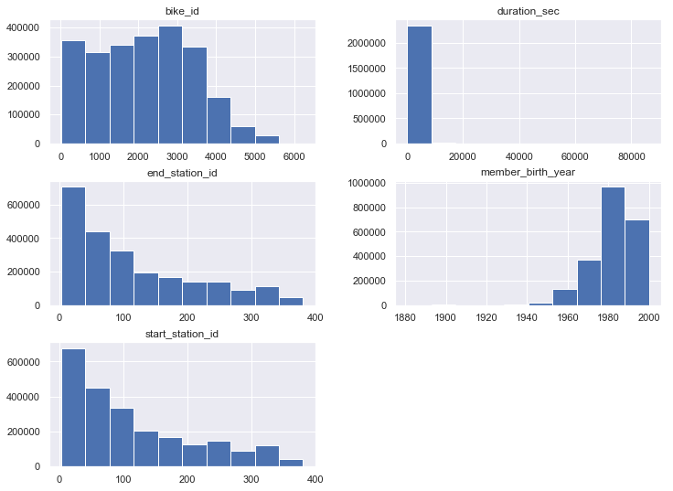

```python
# a first look at the data
df_clean.hist(figsize=(12,9));
```

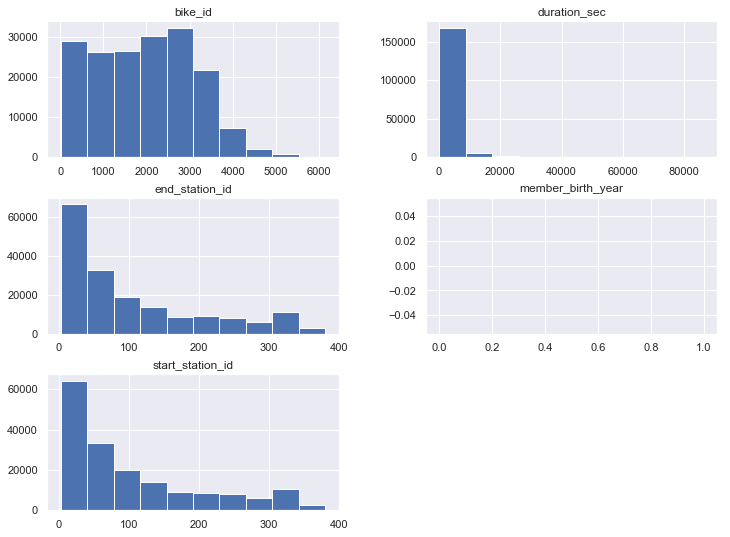

```python
# plot histograms for those instances that there are no birth date data
df_clean[df_clean.member_birth_year.isnull()].hist(figsize=(12,9));
```

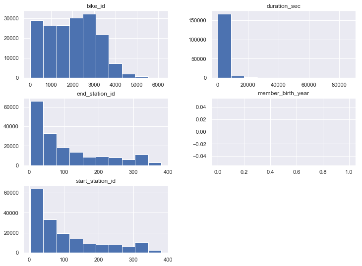

```python
# plot histograms for those instances that there are no gender information
df_clean[df_clean.member_gender.isnull()].hist(figsize=(12,9));
```

We see that the distribution of values for those instances that there are no birth date and gender data are similar to the distribution of the whole dataset. Thus, droping these instances should not affect the data trend.

```python
# further cleaning
index_to_drop = df_clean[df_clean.member_birth_year.isnull()].index
```

```python
df_clean.drop(index_to_drop, inplace = True)
```

```python
index_to_drop = df_clean[df_clean.member_gender.isnull()].index
```

```python
df_clean.drop(index_to_drop, inplace = True)
```

```python
df_clean.reset_index(drop = True, inplace = True)
```

```python
df_clean.info(null_counts=True)
```

```
<class 'pandas.core.frame.DataFrame'>
RangeIndex: 2194715 entries, 0 to 2194714
Data columns (total 11 columns):
duration_sec          2194715 non-null int64
start_time            2194715 non-null datetime64[ns]
end_time              2194715 non-null datetime64[ns]
start_station_id      2194715 non-null int64
start_station_name    2194715 non-null object
end_station_id        2194715 non-null int64
end_station_name      2194715 non-null object
bike_id               2194715 non-null int64
user_type             2194715 non-null category
member_birth_year     2194715 non-null float64
member_gender         2194715 non-null object
dtypes: category(1), datetime64[ns](2), float64(1), int64(4), object(3)
memory usage: 169.5+ MB
```

A first look a the data reveals some insights. For example, some bike ids have been used more than others, or stations with small id numbers are busiest than onthers. We need however to look at the data in higher resolution.

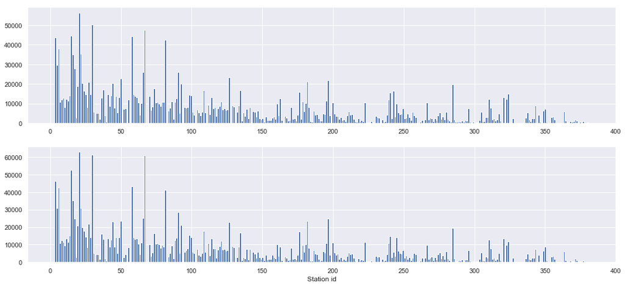

```python
# Busiest start and end stations by ids
#df_clean.start_station_id.hist(bins = 100, figsize = (12,6));

plt.figure(figsize = [18,8])

default_color = sb.color_palette()[0]

plt.subplot(2,1,1)
plt.hist(data = df_clean, x = 'start_station_id', bins = 335)

plt.subplot(2,1,2)
plt.hist(data = df_clean, x = 'end_station_id', bins = 335)
plt.xlabel("Station id");
```

The distribution of the start and end station ids, looks almost identical. I can plot them together:

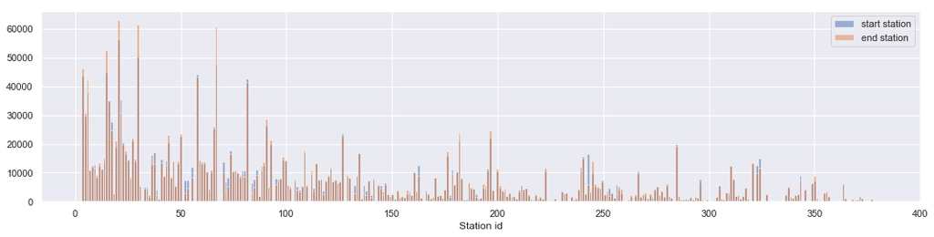

```python
plt.figure(figsize = [18,4])

df_clean.start_station_id.hist(alpha = 0.5, bins = 335, label = 'start station')
df_clean.end_station_id.hist(alpha = 0.5, bins = 335, label = 'end station')
plt.xlabel('Station id')
plt.legend();
```

```python
# expore distribution of busiest start stations from the last month of 2018
df_temp = df_clean[df_clean.start_time >= '2018-12-01']
```

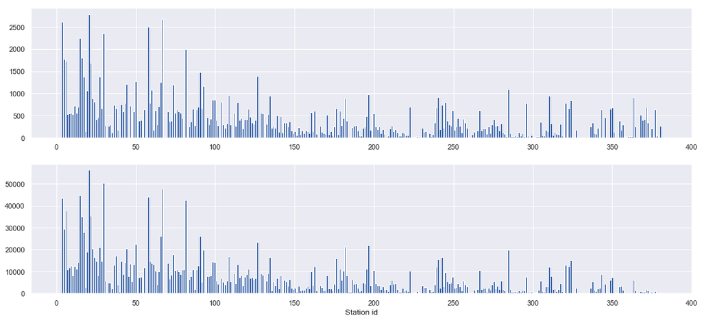

```python
# plot busiest start stations for all dataset, and last month of 2018
plt.figure(figsize = [18,8])

default_color = sb.color_palette()[0]

plt.subplot(2,1,1)
plt.hist(data = df_temp, x = 'start_station_id', bins = 335)

plt.subplot(2,1,2)
plt.hist(data = df_clean, x = 'start_station_id', bins = 335)
plt.xlabel("Station id") ;
```

We see that the distributions of station ids are very similar for the last month of 2018 and the whole period 2017-2018.

I can also explore busiest time during the day.

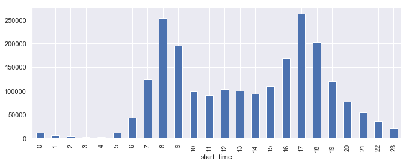

```python
# busiest time in the day by start time
df_clean.groupby(df_clean.start_time.dt.hour).count().start_time.plot(kind = 'bar', figsize = (11,4));
```

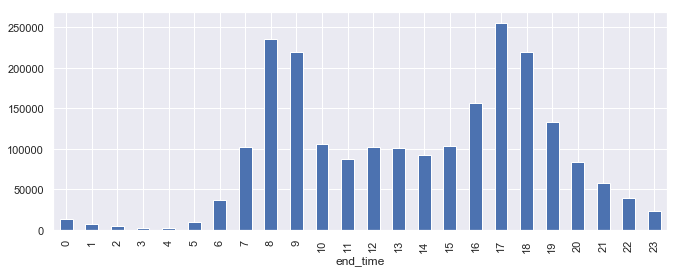

```python
# busiest time in the day by end time
df_clean.groupby(df_clean.end_time.dt.hour).count().end_time.plot(kind = 'bar', figsize = (11,4));
```

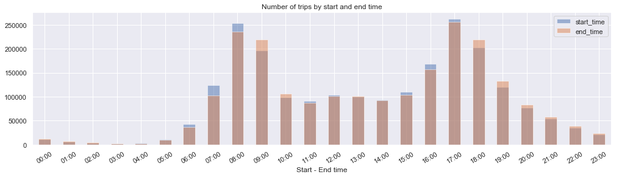

```python
# busiest time in the day by start and end trip time
plt.figure(figsize = [17,4])

df_clean.groupby(df_clean.start_time.dt.hour).count().start_time.plot(alpha = 0.5, kind = 'bar', color = sb.color_palette()[0])
df_clean.groupby(df_clean.end_time.dt.hour).count().end_time.plot(alpha = 0.5, kind = 'bar', color = sb.color_palette()[1])

plt.xlabel('Start - End time')
plt.title('Number of trips by start and end time')

plt.xticks([0, 1, 2, 3, 4, 5, 6, 7, 8, 9, 10, 11, 12, 13, 14, 15, 16, 17, 18, 19, 20, 21, 22, 23],
           ['00:00', '01:00', '02:00', '03:00', '04:00', '05:00', '06:00', '07:00', '08:00', '09:00', '10:00', '11:00',
            '12:00', '13:00', '14:00', '15:00', '16:00', '17:00', '18:00', '19:00', '20:00', '21:00', '22:00', '23:00'])
plt.xticks(rotation = 30)

plt.legend();
```

The time during the date with the highest use of bikes, are between 8 and 9 o'clock in the morning and between 5 and 6 o'clock in the evening. Thus is, the usual rush hours.

*From now on, I will only use the start time or the start station to expore my data.*

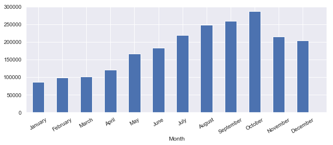

```python
# busiest month by number of trips
df_clean.groupby(df_clean.start_time.dt.month).count().duration_sec.plot(kind = 'bar', figsize = (11,4))

plt.xlabel('Month')

plt.xticks([0, 1, 2, 3, 4, 5, 6, 7, 8, 9, 10, 11, 12],
           ['January', 'February', 'March', 'April', 'May', 'June',
            'July', 'August', 'September', 'October', 'November', 'December'])

plt.xticks(rotation = 30);
```

October is the month with the highest number of trips. We also see a big drop after October, for the months November and December. That might be because of the weather or other reasons. It would be interesting to explore also 2019 in order to see if bike trips increase again after winter months. I can also check the years 2017 and 2018 separatelly:

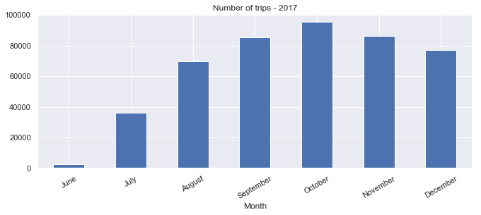

```python
# number of trips per month for 2017

df_clean[df_clean.start_time <= '2017/12/31'].groupby(df_clean.start_time.dt.month).count().duration_sec.plot(kind = 'bar', figsize = (11,4))

plt.title('Number of trips - 2017')
plt.xlabel('Month')

plt.xticks([0, 1, 2, 3, 4, 5, 6],
           ['June', 'July', 'August', 'September', 'October', 'November', 'December'])

plt.xticks(rotation = 30);
```

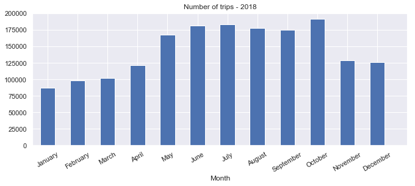

```python
# number of trips per month for 2018

df_clean[df_clean.start_time >= '2018/01/01'].groupby(df_clean.start_time.dt.month).count().duration_sec.plot(kind = 'bar', figsize = (11,4))

plt.xlabel('Month')
plt.title('Number of trips - 2018')

plt.xticks([0, 1, 2, 3, 4, 5, 6, 7, 8, 9, 10, 11, 12],
           ['January', 'February', 'March', 'April', 'May', 'June',
            'July', 'August', 'September', 'October', 'November', 'December'])

plt.xticks(rotation = 30);
```

We indeed see in both years that afer October there is a drop in the number of trips.

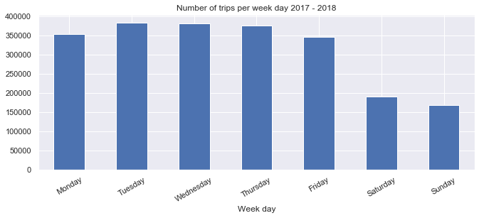

```python
# number of trips by week day

df_clean.groupby(df_clean.start_time.dt.dayofweek).count().duration_sec.plot(kind = 'bar', figsize = (11,4))

plt.title('Number of trips per week day 2017 - 2018')
plt.xlabel('Week day')

plt.xticks([0, 1, 2, 3, 4, 5, 6],
           ['Monday', 'Tuesday', 'Wednesday', 'Thursday', 'Friday', 'Saturday', 'Sunday'])

plt.xticks(rotation = 30);
```

We see that the majority of the trips are during the working days, which is an indicator - together with the previous plot which shows that the busiest time is the rush hours - that people are mostly using the bikes to and from work.

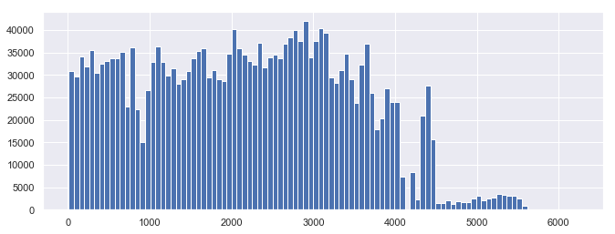

```python
# number of times bike ids have been used
df_clean.bike_id.hist(figsize = (11,4), bins = 100);
```

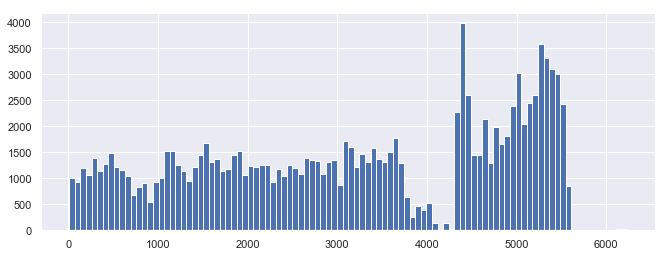

```python
# number of times bike ids have been used for the last month of 2018
df_clean[df_clean.start_time >= '2018/12/01'].bike_id.hist(figsize = (11,4), bins = 100);
```

Interestingly, the bikes with the highest id numbers have been mostly used the last month of 2018. Maybe these are the newest bikes and have been placed to more busiest stations.

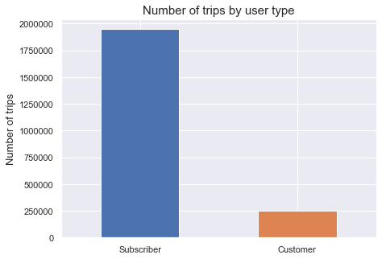

```python
# number of trips by subscribers and customers
plt.figure(figsize = (7,5))
df_clean.user_type.value_counts().plot(kind = 'bar', color = [sb.color_palette()[0], sb.color_palette()[1]])
plt.title('Number of trips by user type', fontdict={'fontsize':15})
plt.xticks(rotation = 0)
plt.ylabel('Number of trips', fontdict={'fontsize':13});
```

```python
df_clean.member_birth_year.nunique()
```

```
88
```

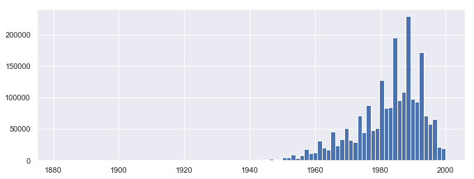

```python
# members' birth year distribution
df_clean.member_birth_year.hist(bins = 88, figsize = (11,4));
```

```python
(df_clean.member_birth_year < 1930).sum()
```

```
1892
```

```python
(df_clean.member_birth_year < 1940).sum()
```

```
3248
```

We see that 1892 of the birth year values are below 1930. That means people above 87 years old. These values are probably erroneous. Also, about 3248 values are below 1940, that is people above 77 years old. We cannot be sure if there are really people above 77 years old that drive electric bikes in the city, but that seems unlikely.

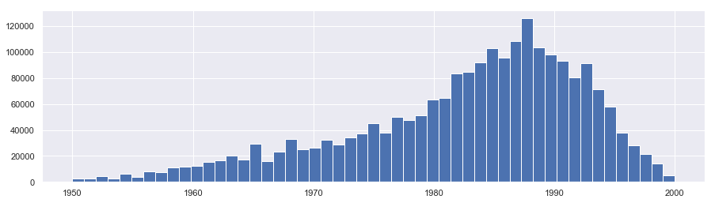

```python
# plot only those born after 1950
df_clean[(df_clean.member_birth_year >=1950)].member_birth_year.hist(figsize = (15,4), bins = 51);
```

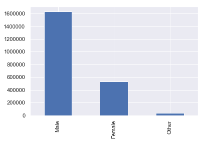

```python
# bike trips by gender
df_clean.member_gender.value_counts().plot(kind = 'bar');
```

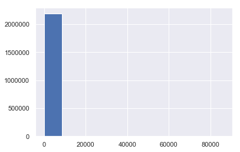

```python
# duration of trips
df_clean.duration_sec.hist();
```

Here probably there are some outlier values. I should zoom in the smaller duration values.

```python
df_clean.duration_sec.max()
```

```
86281
```

```python
df_clean.duration_sec.max()/3600
```

```
23.966944444444444
```

The max duration value for a trip is almost 24 hours!

```python
df_clean.duration_sec.quantile(0.98)
```

```
2480.0
```

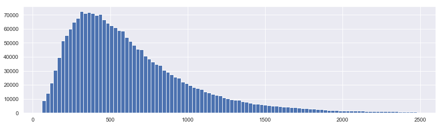

```python
# duration distribution for 98th percentile
df_clean[df_clean.duration_sec <= 2480].duration_sec.hist(figsize = (15,4), bins = 100);
```

This is however in seconds. Let's plot it in minutes so that it becomes more clear.

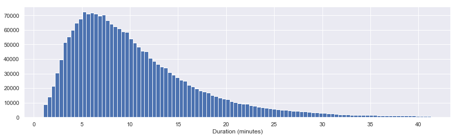

```python
(df_clean[df_clean.duration_sec <= 2480].duration_sec/60).hist(figsize = (15,4), bins = 100)
plt.xlabel('Duration (minutes)');
```

### Discuss the distribution(s) of your variable(s) of interest. Were there any unusual points? Did you need to perform any transformations?

Of the variables of interest we saw that, for the whole population, most trips happen during the rush hours and during the week days. The majority of the population in the dataset, most likely uses the bikes to/from work.

Also the number of trips for subscribers is much higher than that of customers, meaning that the majority of people using the bikes are subscribers.

Moreover, I noticed that the pick number of trips is in October with a decrease in the trips for the months November and December. I also plotted the number of trips for 2017 and 2018 together but also separatelly, in order to see if the drop in the numbers of trips is something that happened in both years.

### Of the features you investigated, were there any unusual distributions? Did you perform any operations on the data to tidy, adjust, or change the form of the data? If so, why did you do this?

There were some birth year values that are erroneous, e.g. for people born before 1900, as well as birth year values for very old people beyond 87 years old , that might be erroneous. For the birth year I plotted the distributions of those born above 1950, thus exluding some outliers.

For the trip durations, the max value identified is almost 24 hours! For the duration, I have plotted the values below the 98th percentile, again exluding the outliers. Furthermore, since the duration is in seconds I also plotted the duration in minutes to make the outcome more clear.

Finally, the bikes with high id numbers have been used mostly the last month of 2018. That might be explained if these are the newest bikes that have been placed in the busiest stations.

## Bivariate Exploration

I will plot here the age distribution in box plots in order to more clearly show the outliers.

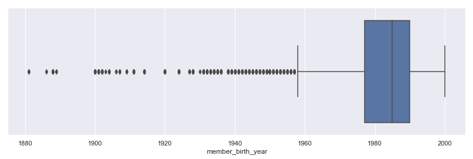

```python
# age exploration
plt.figure(figsize = (14,4))
sb.boxplot(data = df_clean, x = 'member_birth_year');
```

Indeed, we can again see here, that there are outliers for people with old age. I can plot the exact age, using 2018 as a reference year:

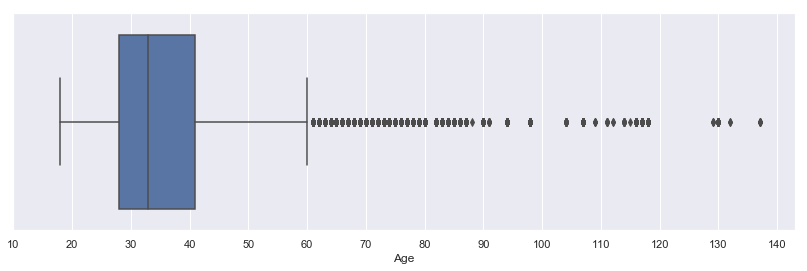

```python
# age exploration
plt.figure(figsize = (14,4))
sb.boxplot(data = (2018 - df_clean.member_birth_year), orient = 'h')
plt.xlabel('Age')
plt.yticks([0], [''])
plt.xticks(np.arange(10, (2018 - df_clean.member_birth_year + 10).max(), 10));
```

```python
# mean age
(2018 - df_clean.member_birth_year).mean()
```

```
35.4876150206291
```

```python
# median age
(2018 - df_clean.member_birth_year).median()
```

```
33.0
```

```python
# mean age for members under 60
(2018 - df_clean[(2018 - df_clean.member_birth_year)<60].member_birth_year).mean()
```

```
34.61061142691902
```

```python
# median age for members under 60
(2018 - df_clean[(2018 - df_clean.member_birth_year)<60].member_birth_year).median()
```

```
33.0
```

For convinience I will create the variable member_age, as a new column, using 2018 as a reference year.

```python
df_clean['member_age'] = 2018 - df_clean.member_birth_year
```

```python
df_clean.info(null_counts=True)
```

```
<class 'pandas.core.frame.DataFrame'>
RangeIndex: 2194715 entries, 0 to 2194714
Data columns (total 12 columns):
duration_sec          2194715 non-null int64
start_time            2194715 non-null datetime64[ns]
end_time              2194715 non-null datetime64[ns]
start_station_id      2194715 non-null int64
start_station_name    2194715 non-null object
end_station_id        2194715 non-null int64
end_station_name      2194715 non-null object
bike_id               2194715 non-null int64
user_type             2194715 non-null category
member_birth_year     2194715 non-null float64
member_gender         2194715 non-null object
member_age            2194715 non-null float64
dtypes: category(1), datetime64[ns](2), float64(2), int64(4), object(3)
memory usage: 186.3+ MB
```

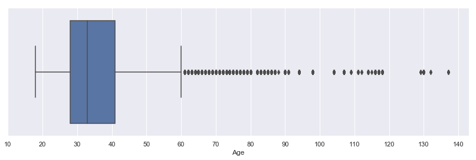

```python
# age exploration
plt.figure(figsize = (14,4))
sb.boxplot(data = df_clean.member_age, orient = 'h')
plt.xlabel('Age')
plt.yticks([0], [''])
plt.xticks(np.arange(10, df_clean.member_age.max()+10, 10));
```

I will create bins, for the different ages groups, in order to explore trends related to the age. I will create bins with the different age groups, from the minimum age until the age of 60. After the age of 60, will be considerd to be in the 60s group, since it is only a small number compared to the size of the dataset.

```python
df_clean.member_age.min(), df_clean.member_age.max()
```

```
(18.0, 137.0)
```

```python
# bin creation
bin_edges = [17, 29, 39, 49, 59, 137]
bin_names = ['20s', '30s', '40s', '50s', '60s']
```

```python
df_clean['decade'] = pd.cut(df_clean.member_age, bin_edges, labels = bin_names)
```

```python
df_clean.head(2)
```

|  | duration_sec | start_time | end_time | start_station_id | start_station_name | end_station_id | end_station_name | bike_id | user_type | member_birth_year | member_gender | member_age | decade |
| --- | --- | --- | --- | --- | --- | --- | --- | --- | --- | --- | --- | --- | --- |
| 0 | 80110 | 2017-12-31 16:57:39.654 | 2018-01-01 15:12:50.245 | 74 | Laguna St at Hayes St | 43 | San Francisco Public Library (Grove St at Hyde... | 96 | Customer | 1987.0 | Male | 31.0 | 30s |
| 1 | 78800 | 2017-12-31 15:56:34.842 | 2018-01-01 13:49:55.617 | 284 | Yerba Buena Center for the Arts (Howard St at ... | 96 | Dolores St at 15th St | 88 | Customer | 1965.0 | Female | 53.0 | 50s |

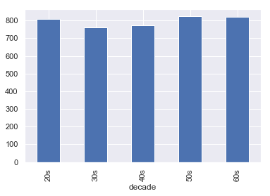

```python
# average duration per decade
df_clean.groupby('decade').mean().duration_sec.plot(kind = 'bar');
```

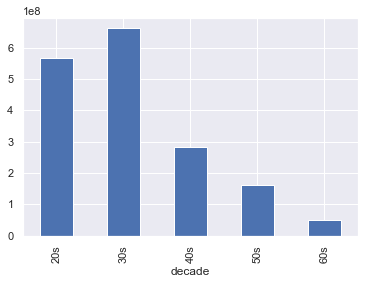

```python
# total duration per decade
df_clean.groupby('decade').sum().duration_sec.plot(kind = 'bar');
```

The total duration is smaller for bigger age groups, most likely due to the less people in these groups:

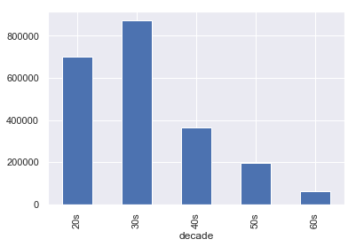

```python
# number of trips per decade
df_clean.groupby('decade').count().duration_sec.plot(kind = 'bar');
```

I will now include an additional variable, that of the user type.

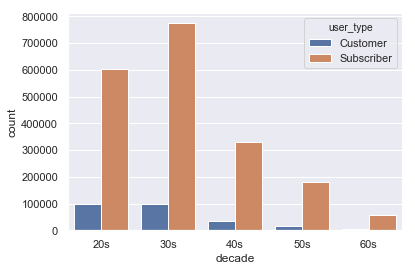

```python
# number of trips per decade per user type
sb.countplot(data = df_clean, x = 'decade', hue = 'user_type');
```

We see that the number of trips for the subscribers are much higher since the number of subscribers is much higher than the customers.

We can also see the number of trips for the different member genders:

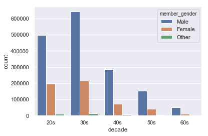

```python
# number of trips per decade per gender
sb.countplot(data = df_clean, x = 'decade', hue = 'member_gender');
```

Male users are much more than the female users and that reflects to the number of trips. We also see that the number of trips for women in their 20s and 30s is almost the same. For men on the other hand, those in their 30s are using much more the bikes than those in their 20s. I can also plot them in a heatmap.

```python
trip_counts = df_clean.groupby(['decade', 'member_gender']).size()
trip_counts = trip_counts.reset_index(name = 'count')
trip_counts = trip_counts.pivot(index = 'member_gender', columns = 'decade', values = 'count')
```

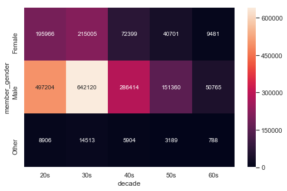

```python
plt.figure(figsize = (8,5))
sb.heatmap(trip_counts, annot = True, fmt = 'd');
```

We notice that results are more clear when I use a clusterred bar chart, instead of a heatmap chart. We can still see that males in their 30s are the largest users of bikes.

I will also explore the busiest times by adding the user type dimension.

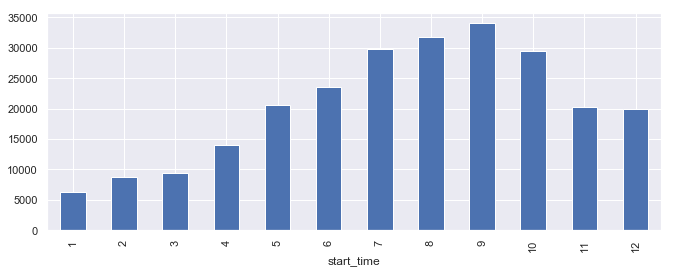

```python
# number of trips by month for customers
df_clean[df_clean.user_type == 'Customer'].groupby(df_clean.start_time.dt.month).count().duration_sec.plot(kind = 'bar', figsize = (11,4));
```

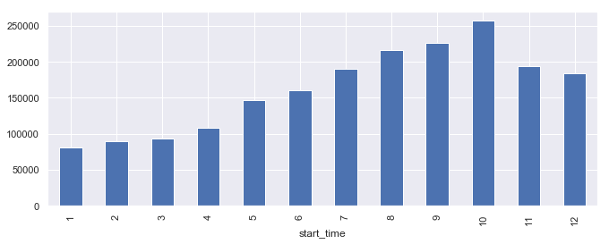

```python
# number of trips by month by subscribers
df_clean[df_clean.user_type == 'Subscriber'].groupby(df_clean.start_time.dt.month).count().duration_sec.plot(kind = 'bar', figsize = (11,4));
```

Interestingly, we see from these graphs that for customers the month with the more bike trips is September and not October. This might be an indicator that customers are visitors at the city and not regular users. I can check the busiest day of week.

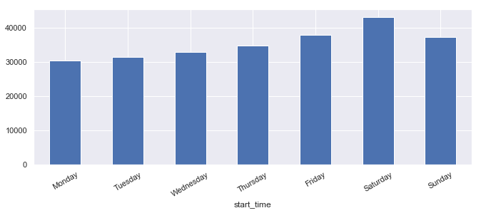

```python
# number of trips by week day for customers
df_clean[df_clean.user_type == 'Customer'].groupby(df_clean.start_time.dt.dayofweek).count().duration_sec.plot(kind = 'bar', figsize = (11,4))
plt.xticks([0, 1, 2, 3, 4, 5, 6],
           ['Monday', 'Tuesday', 'Wednesday', 'Thursday', 'Friday', 'Saturday', 'Sunday'])
plt.xticks(rotation = 30);
```

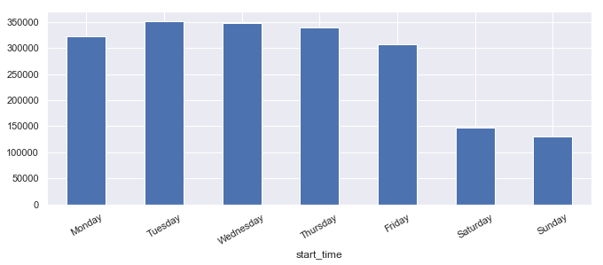

```python
# number of trips by week day for subscribers
df_clean[df_clean.user_type == 'Subscriber'].groupby(df_clean.start_time.dt.dayofweek).count().duration_sec.plot(kind = 'bar', figsize = (11,4))
plt.xticks([0, 1, 2, 3, 4, 5, 6],
           ['Monday', 'Tuesday', 'Wednesday', 'Thursday', 'Friday', 'Saturday', 'Sunday'])
plt.xticks(rotation = 30);
```

Indeed, the highest number of trips for customers is on Saturday followed by Friday and Sunday and with almost equal distribution for the rest of the days, indicating that these are mostly visitors at the city. While for subscribers, they mostly use their bikes during the week with a big drop in the usage during the weekends. I will plot them together:

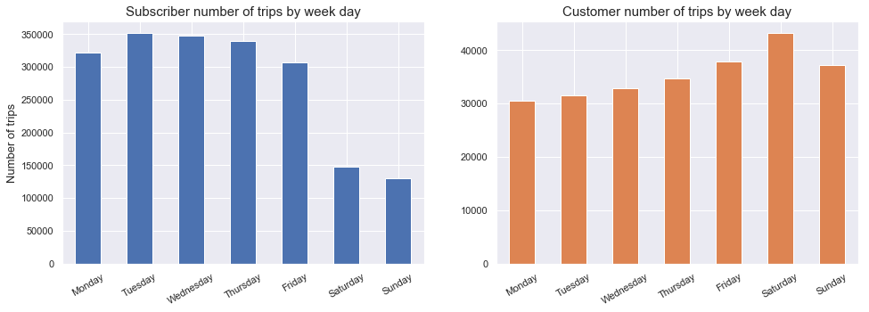

```python
# number of bike trips per week day for subscribers and customers
plt.figure(figsize = (16,5))

plt.subplot(1,2,1)
df_clean[df_clean.user_type == 'Subscriber'].groupby(df_clean.start_time.dt.dayofweek).count().duration_sec.plot(kind = 'bar', color = sb.color_palette()[0])
plt.xlabel('')
plt.ylabel('Number of trips', fontdict={'fontsize':13})
plt.title('Subscriber number of trips by week day', fontdict={'fontsize':15})
plt.xticks([0, 1, 2, 3, 4, 5, 6],
           ['Monday', 'Tuesday', 'Wednesday', 'Thursday', 'Friday', 'Saturday', 'Sunday'])
plt.xticks(rotation = 30)

plt.subplot(1,2,2)
df_clean[df_clean.user_type == 'Customer'].groupby(df_clean.start_time.dt.dayofweek).count().duration_sec.plot(kind = 'bar', color = sb.color_palette()[1])
plt.xlabel('')
plt.ylabel('')
plt.title('Customer number of trips by week day', fontdict={'fontsize':15})
plt.xticks([0, 1, 2, 3, 4, 5, 6],
           ['Monday', 'Tuesday', 'Wednesday', 'Thursday', 'Friday', 'Saturday', 'Sunday'])
plt.xticks(rotation = 30);
```

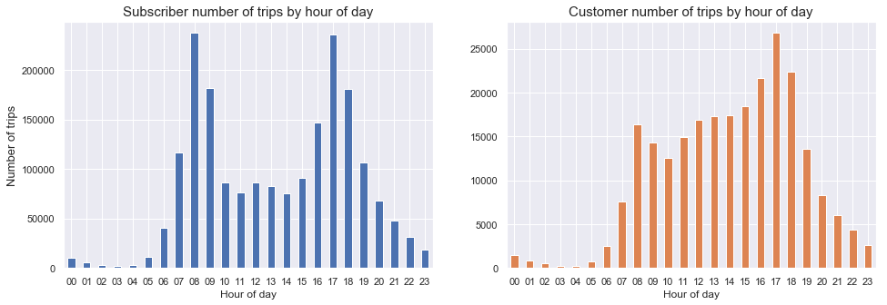

```python
# number of trips per hour for subscribers and customers
plt.figure(figsize = (16,5))

plt.subplot(1,2,1)
df_clean[df_clean.user_type == 'Subscriber'].groupby(df_clean.start_time.dt.hour).count().duration_sec.plot(kind = 'bar', color = sb.color_palette()[0])
plt.xlabel('Hour of day')
plt.ylabel('Number of trips', fontdict={'fontsize':13})
plt.title('Subscriber number of trips by hour of day', fontdict={'fontsize':15})
plt.xticks([0, 1, 2, 3, 4, 5, 6, 7, 8, 9, 10, 11, 12, 13, 14, 15, 16, 17, 18, 19, 20, 21, 22, 23],
           ['00', '01', '02', '03', '04', '05', '06', '07', '08', '09', '10', '11',
            '12', '13', '14', '15', '16', '17', '18', '19', '20', '21', '22', '23'])
plt.xticks(rotation = 0)

plt.subplot(1,2,2)
df_clean[df_clean.user_type == 'Customer'].groupby(df_clean.start_time.dt.hour).count().duration_sec.plot(kind = 'bar', color = sb.color_palette()[1])
plt.xlabel('Hour of day')
plt.ylabel('')
plt.title('Customer number of trips by hour of day', fontdict={'fontsize':15})
plt.xticks([0, 1, 2, 3, 4, 5, 6, 7, 8, 9, 10, 11, 12, 13, 14, 15, 16, 17, 18, 19, 20, 21, 22, 23],
           ['00', '01', '02', '03', '04', '05', '06', '07', '08', '09', '10', '11',
            '12', '13', '14', '15', '16', '17', '18', '19', '20', '21', '22', '23'])
plt.xticks(rotation = 0);
```

Indeed, when I plot the trips by hour during the day, subscribers are mostly using the bikes in the rush hours, while customers mostly in the evening and with almost an equal distribution throughout the day.

I will also check the male and female distribution of trips during the day and hour of the day:

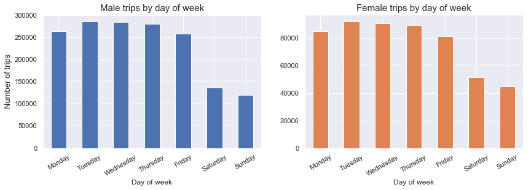

```python
# number of trips per week day for male and female users
plt.figure(figsize = (14,4))

plt.subplot(1,2,1)
df_clean[df_clean.member_gender == 'Male'].groupby(df_clean.start_time.dt.dayofweek).count().duration_sec.plot(kind = 'bar', color = sb.color_palette()[0])
plt.xlabel('Day of week')
plt.ylabel('Number of trips', fontdict={'fontsize':13})
plt.title('Male trips by day of week', fontdict={'fontsize':15})
plt.xticks([0, 1, 2, 3, 4, 5, 6],
           ['Monday', 'Tuesday', 'Wednesday', 'Thursday', 'Friday', 'Saturday', 'Sunday'])
plt.xticks(rotation = 30)

plt.subplot(1,2,2)
df_clean[df_clean.member_gender == 'Female'].groupby(df_clean.start_time.dt.dayofweek).count().duration_sec.plot(kind = 'bar', color = sb.color_palette()[1])
plt.xlabel('Day of week')
plt.ylabel('')
plt.title('Female trips by day of week', fontdict={'fontsize':15})
plt.xticks([0, 1, 2, 3, 4, 5, 6],
           ['Monday', 'Tuesday', 'Wednesday', 'Thursday', 'Friday', 'Saturday', 'Sunday'])
plt.xticks(rotation = 30);
```

There is nothing unexpected here.

Finally, let's explore the trip duration by user type and also gender.

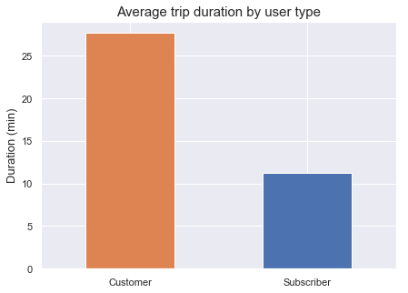

```python
# average trip duration by user type
plt.figure(figsize = (7,5))
(df_clean.groupby('user_type').mean().duration_sec/60).plot(kind = 'bar', color = [sb.color_palette()[1], sb.color_palette()[0]])
plt.title('Average trip duration by user type', fontdict={'fontsize':15})
plt.ylabel('Duration (min)', fontdict={'fontsize':13})
plt.xlabel('')
plt.xticks(rotation = 0);
```

While customers are probably visitors that can spend more time on the bikes.

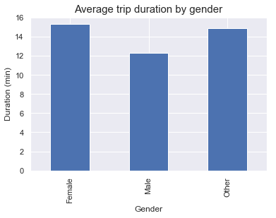

```python
# avg trip duration by gender
(df_clean.groupby('member_gender').mean().duration_sec/60).plot(kind = 'bar')
plt.title('Average trip duration by gender', fontdict={'fontsize':15})
plt.xlabel('Gender')
plt.ylabel('Duration (min)');
```

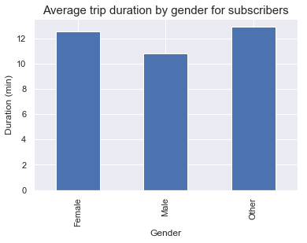

```python
# avg trip duration by gender for subscribers
(df_clean[df_clean.user_type == 'Subscriber'].groupby('member_gender').mean().duration_sec/60).plot(kind = 'bar')
plt.title('Average trip duration by gender for subscribers', fontdict={'fontsize':15})
plt.xlabel('Gender')
plt.ylabel('Duration (min)');
```

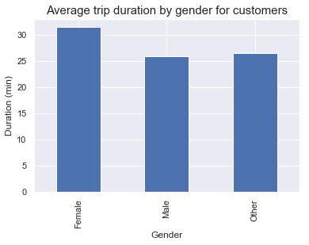

```python
# avg trip duration by gender for customers
(df_clean[df_clean.user_type == 'Customer'].groupby('member_gender').mean().duration_sec/60).plot(kind = 'bar')
plt.title('Average trip duration by gender for customers', fontdict={'fontsize':15})
plt.xlabel('Gender')
plt.ylabel('Duration (min)');
```

Male users are also spending less time in the bikes independently if they are subscribers or customers.

We have identified now the days of the week and the hour of the day with the most bike trips for subscribers and customers, as well as the average trips duration by user type and by gender. We can lastly identify which are the busiest stations. Thus, I will also include the user type dimension to find the busiest stations by number of trips for customers and subscribers. I will focus on the top 10 busiest stations.

```python
df_station = df_clean.groupby(['start_station_name', 'user_type']).size().reset_index(name = 'count')
df_station = df_station.pivot(index = 'start_station_name', columns = 'user_type', values = 'count')
```

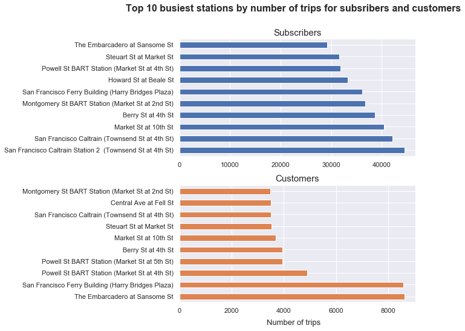

```python
#plt.figure(figsize = (7,8))
fig, ax = plt.subplots(2, 1, figsize=(7, 8))
fig.suptitle('Top 10 busiest stations by number of trips for subsribers and customers', fontsize=16, fontweight = 'bold')
fig.subplots_adjust(hspace=0.25)

#fig.text(-0.48, 0.5, 'Station name', va='center', rotation = 90, fontdict={'fontsize':13, 'fontweight' : 'bold'})
fig.text(0.5, 0.06, 'Number of trips', ha='center', rotation = 0, fontdict={'fontsize':13})

#plt.subplot(2,1,1)
df_station.Subscriber.sort_values(ascending = False).head(10).plot(ax = ax[0], kind = 'barh', color = sb.color_palette()[0])
ax[0].set_title('Subscribers', fontdict={'fontsize':15})
ax[0].set_ylabel('')

#plt.subplot(2,1,2)
df_station.Customer.sort_values(ascending = False).head(10).plot(ax = ax[1], kind = 'barh', color = sb.color_palette()[1])
ax[1].set_title('Customers', fontdict={'fontsize':15})
ax[1].set_ylabel('');
```

We see that the top 10 busiest stations for subscribers and customers differ. For subscribers, for the top 10 busiest stations by number of trips, there is a more "linear" decrease in the "business" of the stations. For customers however, there are two dominant stations by number of trips.

These two stations might be more popular for visitors/tourists. For example, we see that one of them is called "San Francisco Ferry Building" which might be a popular location for visitors activities or an attraction by itself.

Knowing this information can be important, in order for example to have increased service in these two stations, or tourist information and other activities/services.

### Talk about some of the relationships you observed in this part of the investigation. How did the feature(s) of interest vary with other features in the dataset?

Finally, the 10 busiest stations by number of bike trips for subscribers and customers were identified through the visual exploration. The analysis revealed the differences in distributions for the busiest stations for customers and subscribers. For customers, there were two stations that stant out compared to the rest of the stations. That might be explained, if these stations are close to destinations that are popular for the visitors of the city.

### Did you observe any interesting relationships between the other features (not the main feature(s) of interest)?

I have created a new variable decade, for users in their 20s to 60s. We could see in the exploration that the majority of the trips are for male users in their 30s followed by those in their 20s, while for females, the majority of trips are distributed equally for users in their 30s and 20s.

Finally, we could also see that males users spend on average less time per bike trip than female users, independently if they are subscribers or customers!

## Multivariate Exploration

I will plot together the number of trips for subscribers and customers, by day the week and by hour during the day.

```python
# create a new column start day of the week
df_clean['start_day_of_week'] = df_clean.start_time.dt.dayofweek
```

```python
# gather together number of trips per hour and week day for subscribers
df_sub = df_clean[df_clean.user_type == 'Subscriber'].groupby([df_clean.start_time.dt.hour, df_clean.start_day_of_week]).size().reset_index(name = 'count')
df_sub = df_sub.pivot(index = 'start_time', columns = 'start_day_of_week', values = 'count')
```

```python
# gather together number of trips per hour and week day for customers
df_cus = df_clean[df_clean.user_type == 'Customer'].groupby([df_clean.start_time.dt.hour, df_clean.start_day_of_week]).size().reset_index(name = 'count')
df_cus = df_cus.pivot(index = 'start_time', columns = 'start_day_of_week', values = 'count')
```

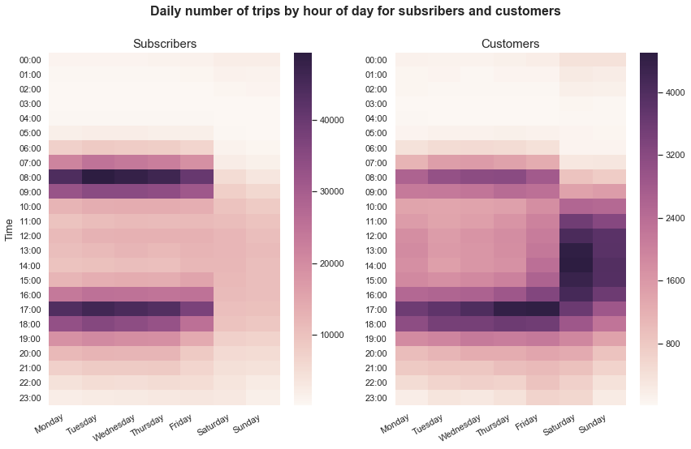

```python
# plot them together using a heatmap
plt.figure(figsize = (14,8))
cmap = sb.cubehelix_palette(as_cmap=True, reverse=False, dark = 0.15, light = 0.97, hue = 0.9)

plt.suptitle('Daily number of trips by hour of day for subsribers and customers', fontsize=16, fontweight = 'bold')

plt.subplot(1,2,1)
sb.heatmap(df_sub, cmap = cmap)

plt.xlabel('')
plt.ylabel('Time', fontdict={'fontsize':13})
plt.title('Subscribers', fontdict={'fontsize':15})

plt.xticks([0, 1, 2, 3, 4, 5, 6],
           ['Monday', 'Tuesday', 'Wednesday', 'Thursday', 'Friday', 'Saturday', 'Sunday'])

plt.yticks([0.5, 1.5, 2.5, 3.5, 4.5, 5.5, 6.5, 7.5, 8.5, 9.5, 10.5, 11.5, 12.5, 13.5, 14.5, 15.5, 16.5, 17.5, 18.5, 19.5, 20.5, 21.5, 22.5, 23.5],
           ['00:00', '01:00', '02:00', '03:00', '04:00', '05:00', '06:00', '07:00', '08:00', '09:00', '10:00', '11:00',
            '12:00', '13:00', '14:00', '15:00', '16:00', '17:00', '18:00', '19:00', '20:00', '21:00', '22:00', '23:00'])

plt.xticks(rotation = 30)
plt.yticks(rotation = 0)

plt.subplot(1,2,2)
sb.heatmap(df_cus, cmap = cmap)

plt.xlabel('')
plt.ylabel('')
plt.title('Customers', fontdict={'fontsize':15})

plt.xticks([0, 1, 2, 3, 4, 5, 6],
           ['Monday', 'Tuesday', 'Wednesday', 'Thursday', 'Friday', 'Saturday', 'Sunday'])

plt.yticks([0.5, 1.5, 2.5, 3.5, 4.5, 5.5, 6.5, 7.5, 8.5, 9.5, 10.5, 11.5, 12.5, 13.5, 14.5, 15.5, 16.5, 17.5, 18.5, 19.5, 20.5, 21.5, 22.5, 23.5],
           ['00:00', '01:00', '02:00', '03:00', '04:00', '05:00', '06:00', '07:00', '08:00', '09:00', '10:00', '11:00',
            '12:00', '13:00', '14:00', '15:00', '16:00', '17:00', '18:00', '19:00', '20:00', '21:00', '22:00', '23:00'])

plt.xticks(rotation = 30)
plt.yticks(rotation = 0);
```

Here we can see in one chart that for subscribers the most trips happen in the week days Mondays to Fridays from 08:00 to 09:00, and from 17:00 to 18:00.

For customers the most trips happen in Thurdsay, Friday, Saturday and Sunday, followed by the other days of the week, and between 13:00 to 18:00.

Next, I will also plot the number of trips for subscribers and customers, by decade and by hour during the day.

```python
df_sub_age = df_clean[df_clean.user_type == 'Subscriber'].groupby([df_clean.start_time.dt.hour, 'decade']).size().reset_index(name = 'count')
df_sub_age = df_sub_age.pivot(index = 'start_time', columns = 'decade', values = 'count')
```

```python
df_cus_age = df_clean[df_clean.user_type == 'Customer'].groupby([df_clean.start_time.dt.hour, 'decade']).size().reset_index(name = 'count')
df_cus_age = df_cus_age.pivot(index = 'start_time', columns = 'decade', values = 'count')
```

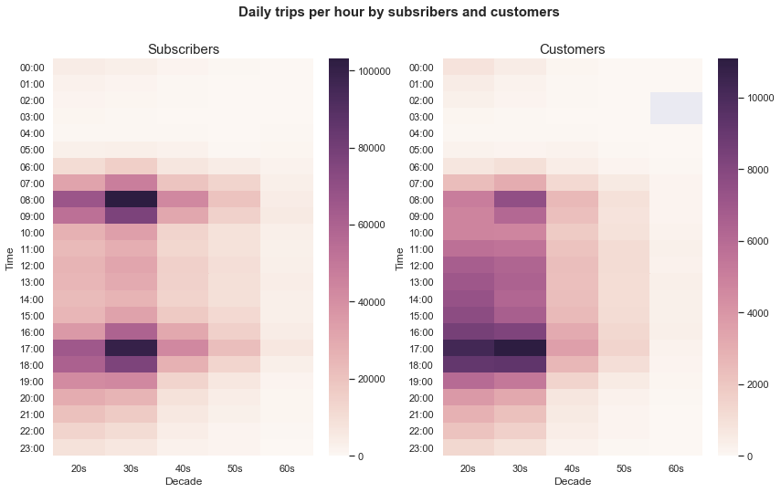

```python
plt.figure(figsize = (14,8))
cmap = sb.cubehelix_palette(as_cmap=True, reverse=False, dark = 0.15, light = 0.97, hue = 0.9)

plt.suptitle('Daily trips per hour by subsribers and customers', fontsize=15, fontweight = 'bold')

plt.subplot(1,2,1)
sb.heatmap(df_sub_age, cmap = cmap)

plt.xlabel('Decade')
plt.ylabel('Time')
plt.title('Subscribers', fontdict={'fontsize':15})

plt.yticks([0.5, 1.5, 2.5, 3.5, 4.5, 5.5, 6.5, 7.5, 8.5, 9.5, 10.5, 11.5, 12.5, 13.5, 14.5, 15.5, 16.5, 17.5, 18.5, 19.5, 20.5, 21.5, 22.5, 23.5],
           ['00:00', '01:00', '02:00', '03:00', '04:00', '05:00', '06:00', '07:00', '08:00', '09:00', '10:00', '11:00',
            '12:00', '13:00', '14:00', '15:00', '16:00', '17:00', '18:00', '19:00', '20:00', '21:00', '22:00', '23:00'])

plt.yticks(rotation = 0)

plt.subplot(1,2,2)
sb.heatmap(df_cus_age, cmap = cmap)

plt.xlabel('Decade')
plt.ylabel('Time')
plt.title('Customers', fontdict={'fontsize':15})

plt.yticks([0.5, 1.5, 2.5, 3.5, 4.5, 5.5, 6.5, 7.5, 8.5, 9.5, 10.5, 11.5, 12.5, 13.5, 14.5, 15.5, 16.5, 17.5, 18.5, 19.5, 20.5, 21.5, 22.5, 23.5],
           ['00:00', '01:00', '02:00', '03:00', '04:00', '05:00', '06:00', '07:00', '08:00', '09:00', '10:00', '11:00',
            '12:00', '13:00', '14:00', '15:00', '16:00', '17:00', '18:00', '19:00', '20:00', '21:00', '22:00', '23:00'])

plt.yticks(rotation = 0);
```

We again see here that the trip distribution is more spread of customers than subscribers, as well as the majority of the users thar are in their 30s and 20s.

Finally, I will explore together the average duration of the trips per user type per decade:

```python
aa = (df_clean.groupby(['decade', 'user_type']).mean().duration_sec/60).reset_index(name = 'avg')
aa = aa.pivot(index = 'decade', columns = 'user_type', values = 'avg')
aa
```

| user_type decade | Customer | Subscriber |
| --- | --- | --- |
| 20s | 28.434480 | 11.059346 |
| 30s | 26.236564 | 10.954101 |
| 40s | 27.474124 | 11.386105 |
| 50s | 30.387270 | 12.374102 |
| 60s | 33.664351 | 12.426241 |

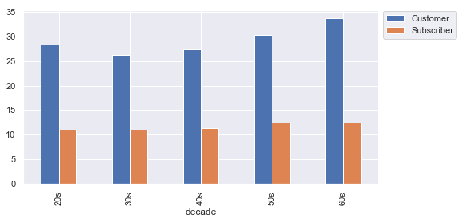

```python
aa.plot(kind = 'bar', figsize = (8,4))
plt.legend(bbox_to_anchor=(1,1.02), loc="upper left");
```

### Talk about some of the relationships you observed in this part of the investigation. Were there features that strengthened each other in terms of looking at your feature(s) of interest?

I plotted together the number of trips for subscribers and customers, by day the week and by hour during the day, in a heatmap type of chart. With that we can clearly see the trends between subscribers and customers. As discussed above, for subscribers, most trips happen in the week days, from Mondays to Fridays, from 08:00 to 09:00, and from 17:00 to 18:00. For customers, most trips happen on Friday, Saturday and Sunday, followed by the other days of the week, and between 13:00 to 18:00.

### Were there any interesting or surprising interactions between features?

We could also see the distribution of the number of trips during the day for the different age groups. The majority of users are in their 30s and 20s, as discused earlier. By adding the hourly numbers of trips, we could also see the distribution of trips per hour per age group for subscribers and customers.

Finally, we could see the average duration of trips for different age groups. Small differences were identified in the average trip duration among the age groups for subscribers, while bigger differences were identified for the different age groups for customers. How much time the different age groups and user types occupy a bike, can be of interest for the planning of the company.

```python
# save file
df_clean.to_csv('df_clean_master.csv', index = False)
```